# Forecasting Car Prices with Linear Regression: A Data-Driven Approach

Gabrielle Felicia Ariyanto

2022-09-02

### **EXPLORATORY DATA ANALYSIS & DATA PRE-PROCESSING**

```r
#load data
carPriceDataFrame <- read.csv("./CarPrice.csv")
```

#### View the data’s dimension and information

```r
dim(carPriceDataFrame)
```

```
## [1] 205  13
```

The dataset has 205 instances and 13 attributes.

```r
str(carPriceDataFrame)
```

```
## 'data.frame':    205 obs. of  13 variables:
##  $ CarID         : int  1 2 3 4 5 6 7 8 9 10 ...
##  $ Symboling     : int  3 3 1 2 2 2 1 1 1 0 ...
##  $ CarName       : chr  "alfa-romero giulia" "alfa-romero stelvio" "alfa-romero Quadrifoglio" "audi 100 ls" ...
##  $ FuelType      : chr  "gas" "gas" "gas" "gas" ...
##  $ Aspiration    : chr  "std" "std" "std" "std" ...
##  $ CarBody       : chr  "convertible" "convertible" "hatchback" "sedan" ...
##  $ WheelBase     : num  88.6 88.6 94.5 99.8 99.4 ...
##  $ CarWidth      : num  64.1 64.1 65.5 66.2 66.4 66.3 71.4 71.4 71.4 67.9 ...
##  $ CurbWeight    : int  2548 2548 2823 2337 2824 2507 2844 2954 3086 3053 ...
##  $ CylinderNumber: chr  "four" "four" "six" "four" ...
##  $ HorsePower    : int  111 111 154 102 115 110 110 110 140 160 ...
##  $ Citympg       : int  21 21 19 24 18 19 19 19 17 16 ...
##  $ Price         : num  13495 16500 16500 13950 17450 ...
```

1. CarID : Each observation identifier (the number of row) -> Data type: Integer
2. Symboling : Insurance risk rating (categorized in -2,-1,0,1,2, and 3) -> Data type : Integer
3. CarName : Name of car -> Data type : Character
4. FuelType : Type of car fuel (categorized in gas and diesel) -> Data type : Character
5. Aspiration : Type of air intake used in a car (categorized in turbo and std) -> Data Type : Character
6. CarBody : Car body type (categorized in convertible, hardtop, hatchback, sedan, and wagon) -> Data type : Character
7. WheelBase : The horizontal distance between the front wheels and the rear wheels of car -> Data type : Numeric
8. CarWidth : The Width of car -> Data type : Numeric
9. CurbWeight : The weight of car with full fuel tank and all standard equipments, without passanger or any baggage-> Data type : Integer
10. CylinderNumber : Number of cylinder the car has(categorized in four, eight, five, six, three, twelve, and two) -> Data type : Character
11. HorsePower : The car engine’s power -> Data type : Integer
12. Citympg : Measures how many miles a car could go through per gallon inside a city (with stopping and braking) -> Data type : Integer
13. Price : The car price -> Data type : Numeric

##### Displays a two-by-two plot showing the proportion of attributes versus to the total number of records (`Record number in dataset`) in the data set. The `Record number in dataset` is assumed as a frequency:

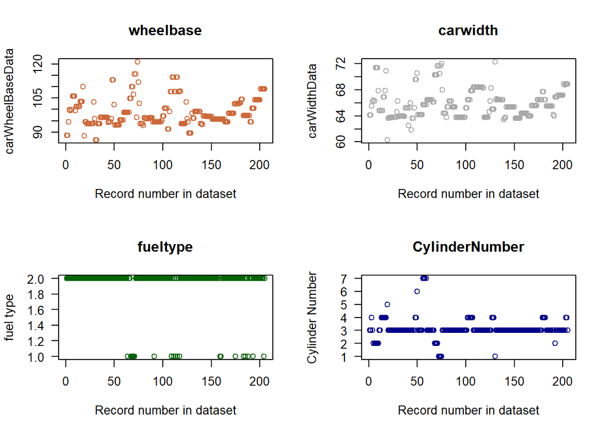

```r
#get wheelBase attribute from the data and store it to 'carWheelBaseData' variable
carWheelBaseData <- carPriceDataFrame$WheelBase
#get carWidth attribute from the data and store it to 'carWidthData' variable
carWidthData <- carPriceDataFrame$CarWidth
#get FuelType attribute from the data and store it to 'carFuelTypeData' variable
carFuelTypeData <- carPriceDataFrame$FuelType
#get CylinderNumber attribute from the data and store it to 'carCylinderNumberData' variable
carCylinderNumberData <- carPriceDataFrame$CylinderNumber

#set two-by-two plot array using mfrow
par(mfrow=c(2,2))
#plot Wheelbase VS it's Record Number at the top left
plot(carWheelBaseData,main="wheelbase",xlab="Record number in dataset",col='sienna3')
#plot carwidth VS it's Record Number at the top right
plot(carWidthData,main="carwidth",xlab="Record number in dataset",col='darkgray')
#plot fueltype VS it's Record Number at the lower left
plot(as.integer(as.factor(carFuelTypeData)),main="fueltype",xlab="Record number in dataset",ylab="fuel type",las=1,col='darkgreen')
#plot CylinderNumber VS it's Record Number at the lower right
plot(as.integer(as.factor(carCylinderNumberData)),main="CylinderNumber",xlab="Record number in dataset",ylab="Cylinder Number",las=1,col='darkblue')
```

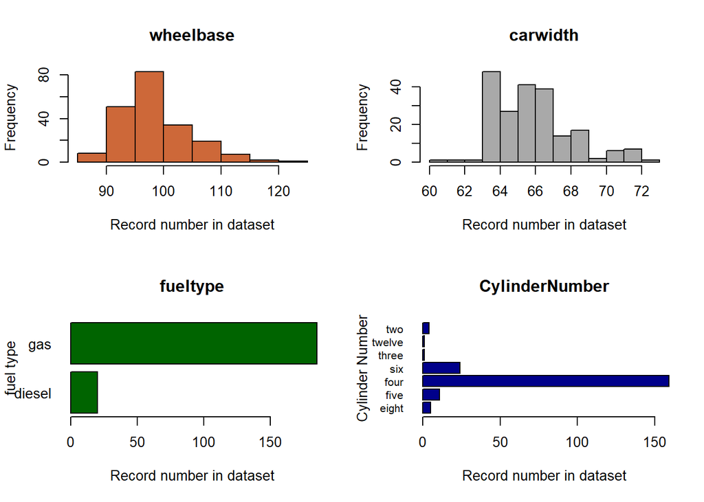

```r
#set two-by-two plot array using mfrow
par(mfrow=c(2,2))
#plot Wheelbase VS it's Record Number at the top left
hist(carWheelBaseData,main="wheelbase",xlab="Record number in dataset",col='sienna3')
#plot carwidth VS it's Record Number at the top right
hist(carWidthData,main="carwidth",xlab="Record number in dataset",col='darkgray')
#plot fueltype VS it's Record Number at the lower left
plot(as.factor(carFuelTypeData),horiz=TRUE,main="fueltype",xlab="Record number in dataset",ylab="fuel type",las=1,col='darkgreen')
#plot CylinderNumber VS it's Record Number at the lower right
plot(as.factor(carCylinderNumberData),horiz=TRUE,main="CylinderNumber",xlab="Record number in dataset",ylab="Cylinder Number",las=1,col='darkblue',cex.names=0.8)
```

Here is the minimum and maximum value of wheelBase attribute and carWidth attribute.

```r
cat("Minimum value of wheel base : ",min(carWheelBaseData),"\n")
```

```
## Minimum value of wheel base :  86.6
```

```r
cat("Maximum value of wheel base : ",max(carWheelBaseData),"\n")
```

```
## Maximum value of wheel base :  120.9
```

```r
cat("Minimum value of car width : ",min(carWidthData),"\n")
```

```
## Minimum value of car width :  60.3
```

```r
cat("Maximum value of car width : ",max(carWidthData),"\n")
```

```
## Maximum value of car width :  72.3
```

[output not shown]

#### Display a mosaic plot to see the relationship between the variables `Carbody` and `CylinderNumber` in the `CarPrice` dataset.

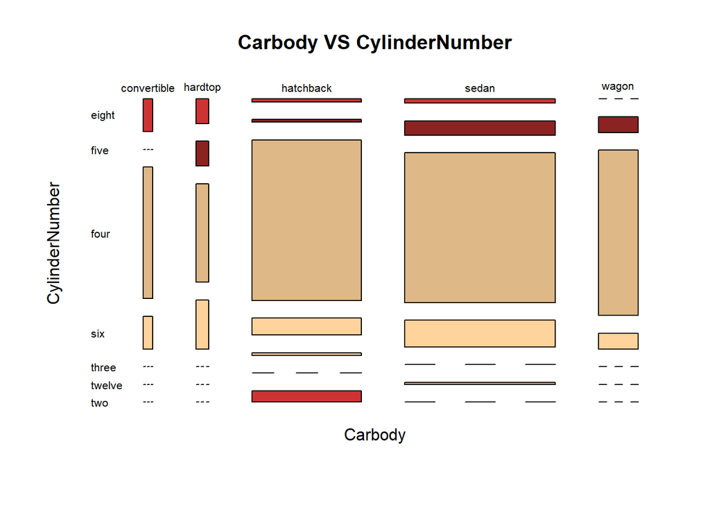

[output not shown]

```r
#get Carbody variable from the data and store it to 'carBodycolumn' variable
carBodycolumn <- carPriceDataFrame$CarBody
#get CylinderNumber variable from the data and store it to 'CylinderNumber' variable
cylinderNumbercolumn <- carPriceDataFrame$CylinderNumber
#plot the relationship between the variables `Carbody` and `CylinderNumber` in the `carPriceDataFrame`
mosaicplot(carBodycolumn~cylinderNumbercolumn,las=1,off=35,xlab="Carbody",ylab="CylinderNumber",main="Carbody VS CylinderNumber",color=colors()[35:40])
```

##### Detect univariate outliers for `wheelbase` attribute

Detect outliers using the three-sigma edit rule

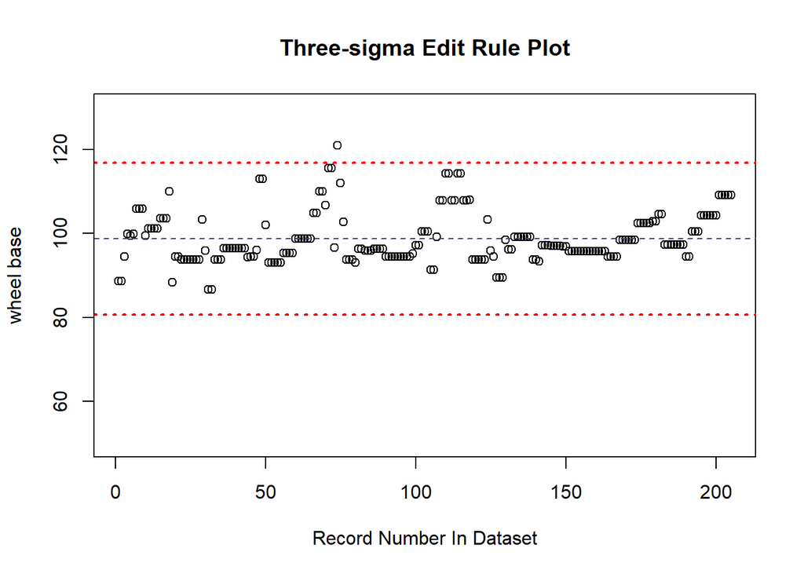

```r
#three-sigma edit rule

#get wheelbase attribute from the carPriceDataFrame and store it to the wheelBaseData variable
wheelBaseData<-carPriceDataFrame$WheelBase

#get the mean of wheelbase attribute
wheelBaseDataMean <-mean(wheelBaseData, na.rm=TRUE)

#get the standard deviation of wheelbase attribute
wheelBaseDataSd <-sd(wheelBaseData, na.rm=TRUE)


#define the upper and lower limit for the three-sigma edit rule to find outliers.
#The formula for three-sigma edit rule is (mean - t x standardDeviation) to find the lower limit and (mean + t x standardDeviation) to find the upper limit with t=3.
t <- 3
upperLimit <- wheelBaseDataMean+t*wheelBaseDataSd
lowerLimit <- wheelBaseDataMean-t*wheelBaseDataSd

#plot the wheelbase data
plot(wheelBaseData ,xlab="Record Number In Dataset", ylab="wheel base",main = "Three-sigma Edit Rule Plot", ylim=c(50,130))
#draw horizontal lines at the mean
abline(h = wheelBaseDataMean,lty="dashed", lwd=1, col="darkslateblue")
#draw the upper and lower outlier detection limits for the three-sigma edit rule
abline(h = upperLimit, lty="dotted", lwd=2, col="red")
abline(h = lowerLimit, lty="dotted", lwd=2, col="red")
```

Detect outliers using the hampel identifier

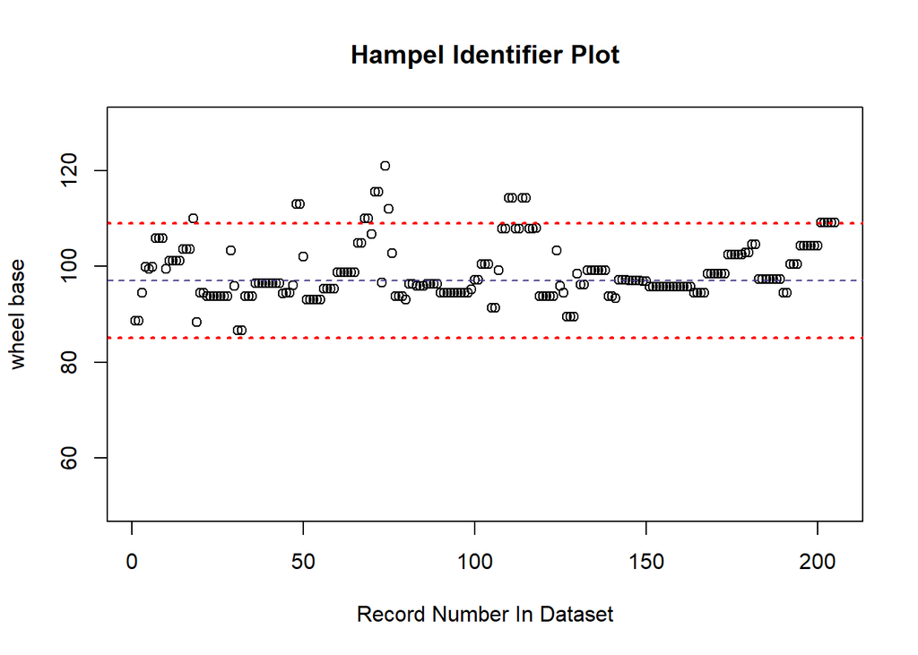

```r
#Hampel identifier

#get the median of wheelbase attribute
wheelBaseDataMedian <-median(wheelBaseData, na.rm=TRUE)

#get the MAD of wheelbase attribute
wheelBaseDataMAD <-mad(wheelBaseData, na.rm=TRUE)

#define the upper and lower limit for the Hampel identifier to find outliers.
#The formula of Hampel identifier is  (median - t x MAD) to find the lower limit and (median + t x MAD) to find the upper limit with t=3.
t <- 3
H_UpperLimit <- wheelBaseDataMedian+t*wheelBaseDataMAD
H_LowerLimit <- wheelBaseDataMedian-t*wheelBaseDataMAD

#plot the wheelbase data
plot(wheelBaseData ,xlab="Record Number In Dataset", ylab="wheel base",main = "Hampel Identifier Plot", ylim=c(50,130))
#draw horizontal lines at the median
abline(h = wheelBaseDataMedian,lty="dashed", lwd=1, col="darkslateblue")
#draw the upper and lower outlier detection limits for the Hampel identifier
abline(h = H_UpperLimit, lty="dotted", lwd=2, col="red")
abline(h = H_LowerLimit, lty="dotted", lwd=2, col="red")
```

Detect outliers using boxplot

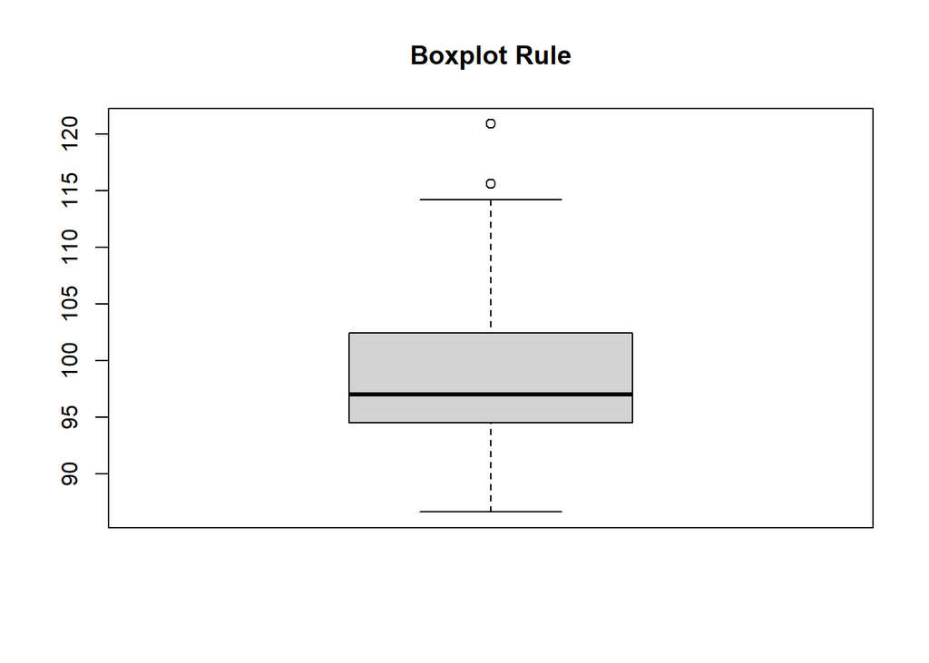

```r
boxplot(wheelBaseData,main = "Boxplot Rule")
```

Below are the summary of the three method for detecting the outliers. For a comparison, the plot are also generated side by side.

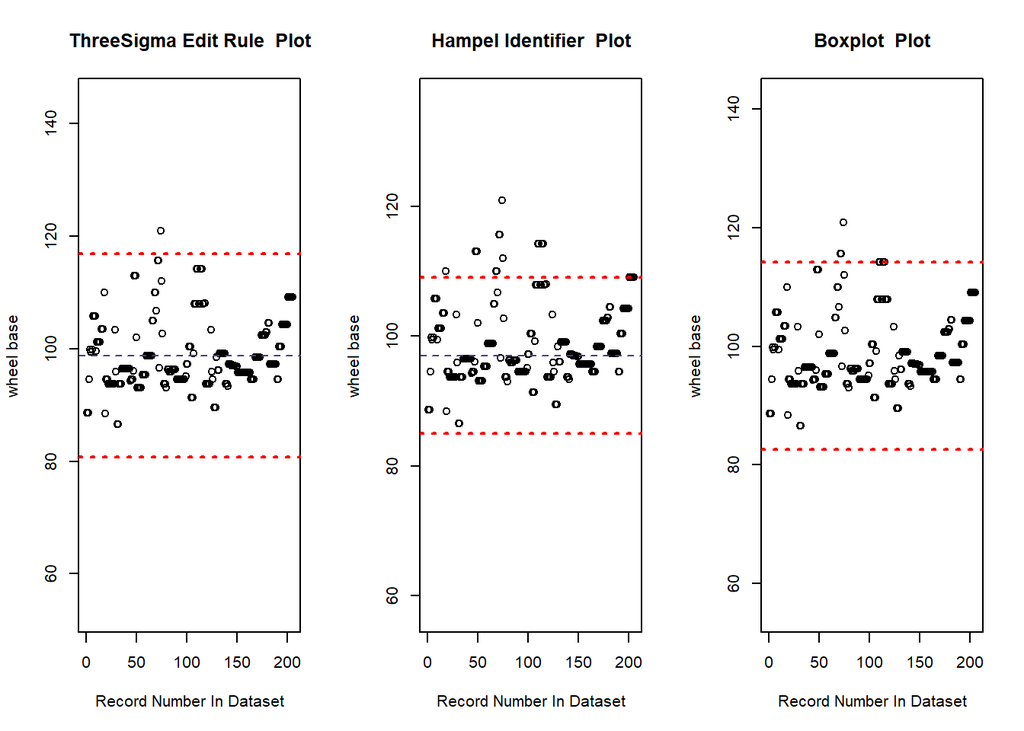

```
##          name totalOutliers lowerLimit upperLimit
## 1  ThreeSigma             1   80.69126   116.8219
## 2      Hampel            18   84.99094   109.0091
## 3 BoxplotRule             3   82.65000   114.2500
```

```r
#building three sigma rule function
ThreeSigmaRule <- function(attribute,t=3) {
  meanAttribute <- mean(attribute, na.rm = TRUE)
  stdAttribute <- sd(attribute, na.rm = TRUE)
  unusualnessThreshold = t*stdAttribute
  upperLimit <- meanAttribute+unusualnessThreshold
  lowerLimit <- meanAttribute-unusualnessThreshold
  return (list(name="ThreeSigma Edit Rule",attribute=attribute,upperLimit=upperLimit, lowerLimit=lowerLimit,typical = meanAttribute))
}

#building hampel identifier function
HampelIdentifier <- function(attribute, t = 3) {
  medianAttribute <- median(attribute, na.rm = TRUE)
  madAttribute <- mad(attribute, na.rm = TRUE)
  unusualnessThreshold = t*madAttribute
  upperLimit <- medianAttribute +unusualnessThreshold
  lowerLimit <- medianAttribute - unusualnessThreshold
  return(list(name="Hampel Identifier",attribute=attribute,upperLimit = upperLimit, lowerLimit = lowerLimit,typical = medianAttribute))
}

#building boxplot rule function
BoxplotRule <- function(attribute, t = 1.5) {
  Q1 <- quantile(attribute, na.rm = TRUE,probs=0.25,names=FALSE)
  Q3 <- quantile(attribute, na.rm = TRUE,probs=0.75,names=FALSE)
  IQR <- Q3-Q1
  unusualnessThreshold =t * IQR
  upperLimit <- Q3 + unusualnessThreshold
  lowerLimit <- Q1 - unusualnessThreshold
  return(list(name="Boxplot",attribute=attribute,upperLimit = upperLimit, lowerLimit = lowerLimit,typicalLower = Q1, typicalUpper=Q3))
}

#build outliers summary of each technique detection
summarizeDetail <- function(name,x, up,down){
  dataLabel <- rep("Normal", length(x))
  indexLowOutlier <- which(x < down)
  indexUpOutlier <- which(x > up)
  dataLabel[indexLowOutlier] <- "LowOutlier"
  dataLabel[indexUpOutlier] <- "UpOutlier"
  indexOutlier <- union(indexLowOutlier, indexUpOutlier)
  valuesOutlier <- x[indexOutlier]
  dataLabel <- dataLabel[indexOutlier]
  totalOutliers <- length(indexOutlier)

  return (
    list(
      name = name,
      totalOutliers = totalOutliers,
      upperLimit = up,
      lowerLimit = down,
      indexOutlier = indexOutlier,
      valuesOutlier = valuesOutlier,
      dataLabel = dataLabel
    )
  )
}

#build a function that represent all detection outliers result in a dataframe and plot for each technique in a one canvas.
detectOutliers <- function(attribute) {
  threeSigmaBound <- ThreeSigmaRule(attribute)
  HampelBound <- HampelIdentifier(attribute)
  boxplotBound <- BoxplotRule(attribute)

  plotDataList<-list(threeSigmaBound,HampelBound,boxplotBound)
  details <- list(summarizeDetail("ThreeSigma",attribute, threeSigmaBound$upperLimit, threeSigmaBound$lowerLimit),
               summarizeDetail("Hampel",attribute, HampelBound$upperLimit, HampelBound$lowerLimit),
               summarizeDetail("BoxplotRule",attribute, boxplotBound$upperLimit, boxplotBound$lowerLimit))

  summary<-data.frame()
  for(detail in details){
      summary <-rbind.data.frame(summary,data.frame(
          method = detail["name"],
          totalOutliers = detail["totalOutliers"],
          lowerLimit = detail["lowerLimit"],
          upperLimit = detail["upperLimit"]
      ))
  }

  par(mfrow=c(1,3))
  for(plotData in plotDataList){
    range=max(plotData$attribute)-min(plotData$attribute)
    ylimMin = min(c(plotData$attribute,plotData$lowerLimit-0.8*range))
    ylimMax = max(c(plotData$attribute,plotData$upperLimit+0.8*range))
    plot(plotData$attribute,
           xlab="Record Number In Dataset", ylab="wheel base",
           main = paste(plotData$name," Plot"), ylim=c(ylimMin,ylimMax))
    if(plotData["name"]=="BoxplotRule"){
      abline(h = plotData$typicalUpper,lty="dashed", lwd=1, col="darkslateblue")
      abline(h = plotData$typicalLower,lty="dashed", lwd=1, col="darkslateblue")
    }else{
      abline(h = plotData$typical,lty="dashed", lwd=1, col="darkslateblue")
    }
    abline(h = plotData$upperLimit, lty="dotted", lwd=2, col="red")
    abline(h = plotData$lowerLimit, lty="dotted", lwd=2, col="red")
  }

  summary
}

detectOutliers(carPriceDataFrame$WheelBase)
```

Below, I also plotted a qq-plot to show which technique is better to detect outlier for this data/case based on it’s outlier limit

```r
library(car)
```

```r
#draw qq-plot
qqPlot(carPriceDataFrame$WheelBase,ylim = c(60,130),main="WheelBase Q-Q Plot")
```

```
## [1] 74 71
```

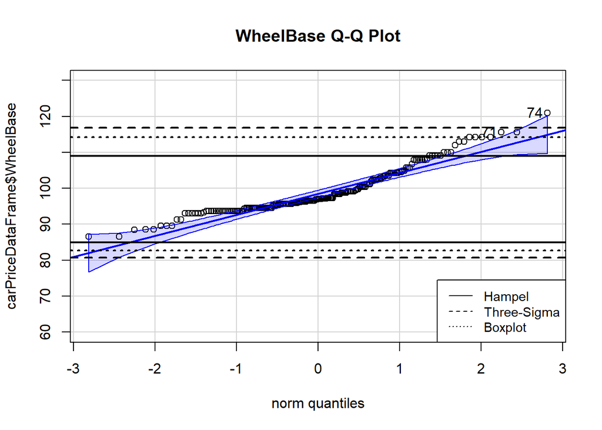

[output not shown]

```r
abline(h = H_UpperLimit, lty=1, lwd=2)
abline(h = H_LowerLimit, lty=1, lwd=2)
abline(h = upperLimit, lty=2, lwd=2)
abline(h = lowerLimit, lty=2, lwd=2)

Q1 <- quantile(carPriceDataFrame$WheelBase, na.rm = TRUE,probs=0.25,names=FALSE)
Q3 <- quantile(carPriceDataFrame$WheelBase, na.rm = TRUE,probs=0.75,names=FALSE)
IQR <- Q3-Q1
unusualnessThreshold =1.5* IQR
BupperLimit <- Q3 + unusualnessThreshold
blowerLimit <- Q1 - unusualnessThreshold
abline(h = BupperLimit, lty=3, lwd=2)
abline(h = blowerLimit, lty=3, lwd=2)

legend(x="bottomright",legend=c("Hampel","Three-Sigma","Boxplot"),
      lty=1:3,cex=0.9)
```

Then, I’d like to determine the number of data points identified as outliers by each technique and assess which outlier detection method appears to produce the most reasonable results based on these identified outliers.

```r
#use subset() function to select and filter values that are declared as outliers by the three-sigma edit rule
Three_sigmaOutliersDataPoints <- subset(wheelBaseData,wheelBaseData<lowerLimit | wheelBaseData>upperLimit)
#Compute how many data points are declared outliers by the three-sigma edit rule
totalThree_SigmaOutliers <- length(Three_sigmaOutliersDataPoints)

#use subset() function to select and filter values that are declared as outliers by the Hampel identifier
HampelOutliersDataPoints <- subset(wheelBaseData,wheelBaseData<H_LowerLimit | wheelBaseData>H_UpperLimit)
#Compute how many data points are declared outliers by the Hampel identifier
totalHampelOutliers <- length(HampelOutliersDataPoints)


Q1 <- quantile(wheelBaseData,probs=0.25,na.rm=TRUE)
Q3 <- quantile(wheelBaseData,probs=0.75,na.rm=TRUE)
IQR <- Q3-Q1
boxPlotUpperLimit <- Q3+1.5*IQR
boxPlotLowerLimit <- Q1-1.5*IQR
#use subset() function to select and filter values that are declared as outliers by the boxplot rule
BoxPlotOutliersDataPoints <- subset(wheelBaseData,wheelBaseData<boxPlotLowerLimit | wheelBaseData>boxPlotUpperLimit)
#Compute how many data points are declared outliers by the boxplot rule
totalBoxPlotOutliers <- length(BoxPlotOutliersDataPoints)

#Make a dataframe that summarize how many and the values of  data points that detected outliers by each technique
OutliersDetected <- c(totalThree_SigmaOutliers,totalHampelOutliers,totalBoxPlotOutliers)
Method <-c("Three-Sigma","Hampel","BoxPlot")

ThreeSigmaData = ""
for(idx in seq_along(Three_sigmaOutliersDataPoints)){
  if(idx>1){
    ThreeSigmaData = paste(ThreeSigmaData,",")
  }
  ThreeSigmaData = paste(ThreeSigmaData,Three_sigmaOutliersDataPoints[idx])
}

HampelsData = ""
for(idx in seq_along(HampelOutliersDataPoints)){
  if(idx>1){
    HampelsData = paste(HampelsData,",")
  }
  HampelsData = paste(HampelsData,HampelOutliersDataPoints[idx])
}


BoxPlotData = ""
for(idx in seq_along(BoxPlotOutliersDataPoints)){
  if(idx>1){
    BoxPlotData = paste(BoxPlotData,",")
  }
  BoxPlotData = paste(BoxPlotData,BoxPlotOutliersDataPoints[idx])
}

values<-c(ThreeSigmaData,HampelsData,BoxPlotData)
df <- data.frame(Method,OutliersDetected,values)
df
```

```
##        Method OutliersDetected
## 1 Three-Sigma                1
## 2      Hampel               18
## 3     BoxPlot                3
##                                                                                                                               values
## 1                                                                                                                              120.9
## 2  110 , 113 , 113 , 110 , 110 , 115.6 , 115.6 , 120.9 , 112 , 114.2 , 114.2 , 114.2 , 114.2 , 109.1 , 109.1 , 109.1 , 109.1 , 109.1
## 3                                                                                                              115.6 , 115.6 , 120.9
```

[output not shown]

#### See correlations for all attributes

```r
library(Hmisc)
#Set the recent dataframe to a new variable in order to be modified separately
corrCarPriceDataFrame = carPriceDataFrame

#Change character data type variables in the data to numeric data type variables
corrCarPriceDataFrame$CarName = as.numeric(as.factor(corrCarPriceDataFrame$CarName))
corrCarPriceDataFrame$FuelType = as.numeric(as.factor(corrCarPriceDataFrame$FuelType))
corrCarPriceDataFrame$Aspiration = as.numeric(as.factor(corrCarPriceDataFrame$Aspiration))
corrCarPriceDataFrame$CarBody = as.numeric(as.factor(corrCarPriceDataFrame$CarBody))
corrCarPriceDataFrame$CylinderNumber = as.numeric(as.factor(corrCarPriceDataFrame$CylinderNumber))

#drop carID column, because the carID variable is not needed
corrCarPriceDataFrame = corrCarPriceDataFrame[-c(1)]

#see the correlation among all attribute using rcorr() function
rcorr(as.matrix(corrCarPriceDataFrame),type=c("pearson","spearman"))
```

```
##                Symboling CarName FuelType Aspiration CarBody WheelBase CarWidth
## Symboling           1.00   -0.11     0.19      -0.06   -0.60     -0.53    -0.23
## CarName            -0.11    1.00    -0.07       0.02    0.11      0.01    -0.08
## FuelType            0.19   -0.07     1.00      -0.40   -0.15     -0.31    -0.23
## Aspiration         -0.06    0.02    -0.40       1.00    0.06      0.26     0.30
## CarBody            -0.60    0.11    -0.15       0.06    1.00      0.40     0.13
## WheelBase          -0.53    0.01    -0.31       0.26    0.40      1.00     0.80
## CarWidth           -0.23   -0.08    -0.23       0.30    0.13      0.80     1.00
## CurbWeight         -0.23   -0.06    -0.22       0.32    0.13      0.78     0.87
## CylinderNumber      0.20    0.04     0.11      -0.13   -0.05     -0.18    -0.19
## HorsePower          0.07   -0.10     0.16       0.24   -0.15      0.35     0.64
## Citympg            -0.04    0.10    -0.26      -0.20    0.03     -0.47    -0.64
## Price              -0.08   -0.24    -0.11       0.18   -0.08      0.58     0.76
##                CurbWeight CylinderNumber HorsePower Citympg Price
## Symboling           -0.23           0.20       0.07   -0.04 -0.08
## CarName             -0.06           0.04      -0.10    0.10 -0.24
## FuelType            -0.22           0.11       0.16   -0.26 -0.11
## Aspiration           0.32          -0.13       0.24   -0.20  0.18
## CarBody              0.13          -0.05      -0.15    0.03 -0.08
## WheelBase            0.78          -0.18       0.35   -0.47  0.58
## CarWidth             0.87          -0.19       0.64   -0.64  0.76
## CurbWeight           1.00          -0.05       0.75   -0.76  0.84
## CylinderNumber      -0.05           1.00       0.12   -0.13 -0.03
## HorsePower           0.75           0.12       1.00   -0.80  0.81
## Citympg             -0.76          -0.13      -0.80    1.00 -0.69
## Price                0.84          -0.03       0.81   -0.69  1.00
##
## n= 205
##
##
## P
##                Symboling CarName FuelType Aspiration CarBody WheelBase CarWidth
## Symboling                0.1261  0.0052   0.3938     0.0000  0.0000    0.0008
## CarName        0.1261            0.3369   0.8209     0.1322  0.8952    0.2282
## FuelType       0.0052    0.3369           0.0000     0.0344  0.0000    0.0007
## Aspiration     0.3938    0.8209  0.0000              0.3693  0.0002    0.0000
## CarBody        0.0000    0.1322  0.0344   0.3693             0.0000    0.0598
## WheelBase      0.0000    0.8952  0.0000   0.0002     0.0000            0.0000
## CarWidth       0.0008    0.2282  0.0007   0.0000     0.0598  0.0000
## CurbWeight     0.0010    0.3835  0.0018   0.0000     0.0664  0.0000    0.0000
## CylinderNumber 0.0045    0.5224  0.1143   0.0571     0.4907  0.0081    0.0053
## HorsePower     0.3126    0.1492  0.0188   0.0005     0.0276  0.0000    0.0000
## Citympg        0.6101    0.1453  0.0002   0.0036     0.6519  0.0000    0.0000
## Price          0.2543    0.0005  0.1315   0.0107     0.2313  0.0000    0.0000
##                CurbWeight CylinderNumber HorsePower Citympg Price
## Symboling      0.0010     0.0045         0.3126     0.6101  0.2543
## CarName        0.3835     0.5224         0.1492     0.1453  0.0005
## FuelType       0.0018     0.1143         0.0188     0.0002  0.1315
## Aspiration     0.0000     0.0571         0.0005     0.0036  0.0107
## CarBody        0.0664     0.4907         0.0276     0.6519  0.2313
## WheelBase      0.0000     0.0081         0.0000     0.0000  0.0000
## CarWidth       0.0000     0.0053         0.0000     0.0000  0.0000
## CurbWeight                0.5022         0.0000     0.0000  0.0000
## CylinderNumber 0.5022                    0.0988     0.0709  0.6942
## HorsePower     0.0000     0.0988                    0.0000  0.0000
## Citympg        0.0000     0.0709         0.0000             0.0000
## Price          0.0000     0.6942         0.0000     0.0000
```

The correlation matrix above is visualized as below

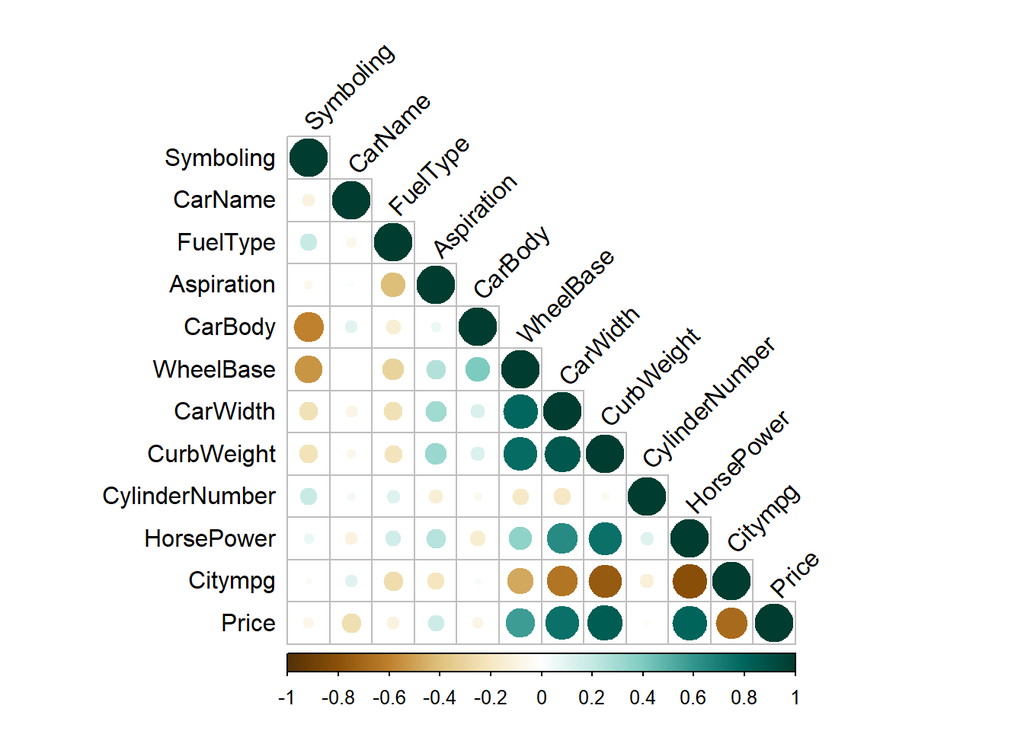

```r
library(corrplot)
corrplot(cor(corrCarPriceDataFrame),type='lower',tl.col='black',tl.srt=45,col=COL2('BrBG'))
```

Below are sorted attribute pair with strongest correlation

```r
library(lares)
```

```
## Returning only the top 25. You may override with the 'top' argument
```

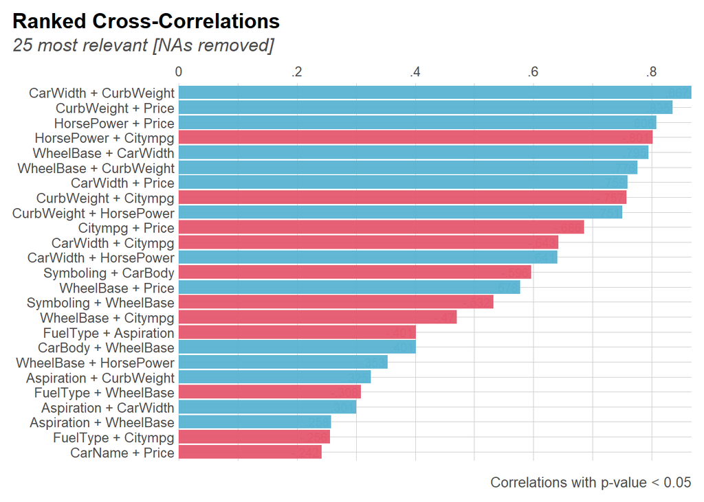

[output not shown]

```r
plot(corr_cross(corrCarPriceDataFrame,rm.na=T,max_pvalue=0.05,type=1,plot=TRUE))
```

#### Detect missing values in the dataset

```r
colSums(is.na(carPriceDataFrame))
```

```
##          CarID      Symboling        CarName       FuelType     Aspiration
##              0              0              0              0              0
##        CarBody      WheelBase       CarWidth     CurbWeight CylinderNumber
##              0              0              0              0              0
##     HorsePower        Citympg          Price
##              0              0              0
```

This car price data doesn’t has any missing values.

#### Change character data type variables in the data to numeric data type variables & drop unnecessary column

```r
library(Hmisc)
#Change character data type variables in the data to numeric data type variables
UpdateCarPriceDataFrame = carPriceDataFrame
UpdateCarPriceDataFrame$CarName = as.numeric(as.factor(UpdateCarPriceDataFrame$CarName))
UpdateCarPriceDataFrame$FuelType = as.numeric(as.factor(UpdateCarPriceDataFrame$FuelType))
UpdateCarPriceDataFrame$Aspiration = as.numeric(as.factor(UpdateCarPriceDataFrame$Aspiration))
UpdateCarPriceDataFrame$CarBody = as.numeric(as.factor(UpdateCarPriceDataFrame$CarBody))
UpdateCarPriceDataFrame$CylinderNumber = as.numeric(as.factor(UpdateCarPriceDataFrame$CylinderNumber))

#drop the carID column from the dataset
UpdateCarPriceDataFrame = UpdateCarPriceDataFrame[-c(1)]

#check whether character data type variables has changed to numeric data type variables or not
str(UpdateCarPriceDataFrame)
```

```
## 'data.frame':    205 obs. of  12 variables:
##  $ Symboling     : int  3 3 1 2 2 2 1 1 1 0 ...
##  $ CarName       : num  1 3 2 4 5 9 5 7 6 8 ...
##  $ FuelType      : num  2 2 2 2 2 2 2 2 2 2 ...
##  $ Aspiration    : num  1 1 1 1 1 1 1 1 2 2 ...
##  $ CarBody       : num  1 1 3 4 4 4 4 5 4 3 ...
##  $ WheelBase     : num  88.6 88.6 94.5 99.8 99.4 ...
##  $ CarWidth      : num  64.1 64.1 65.5 66.2 66.4 66.3 71.4 71.4 71.4 67.9 ...
##  $ CurbWeight    : int  2548 2548 2823 2337 2824 2507 2844 2954 3086 3053 ...
##  $ CylinderNumber: num  3 3 4 3 2 2 2 2 2 2 ...
##  $ HorsePower    : int  111 111 154 102 115 110 110 110 140 160 ...
##  $ Citympg       : int  21 21 19 24 18 19 19 19 17 16 ...
##  $ Price         : num  13495 16500 16500 13950 17450 ...
```

The carID column is dropped because the carID variable is not needed for any correlation. The character data type variables has changed to numeric data type variables.

```r
#see the mean for each numerical variables
sapply(UpdateCarPriceDataFrame[,c(6:8,10:12)],mean,na.rm=TRUE)
```

```
##   WheelBase    CarWidth  CurbWeight  HorsePower     Citympg       Price
##    98.75659    65.90780  2555.56585   104.11707    25.21951 13276.71057
```

From the output above, the mean for the wheelBase variable is around 99, the mean for carWidth is around 66, the mean for curbWeight variable is around 2556, the mean for the HorsePower variable is around 104, the mean for the Citympg variable is around 25, and the mean for the Price variable is around 13277. The highest mean is the Price variable.

#### Check and Remove outliers for price attribute

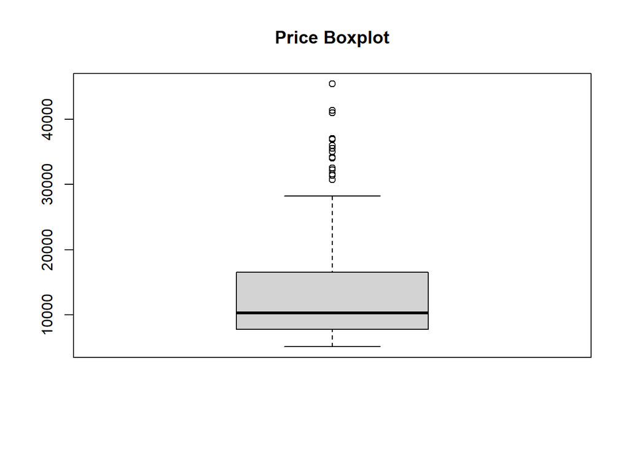

```r
#here I use boxplot to see any outliers for price variable
boxplot(UpdateCarPriceDataFrame$Price,main="Price Boxplot")
```

There are some data points detected as outliers.

Next, check and see the data anomalies for price attribute using three-sigma edit rule, hampel identifier, and boxplot rule

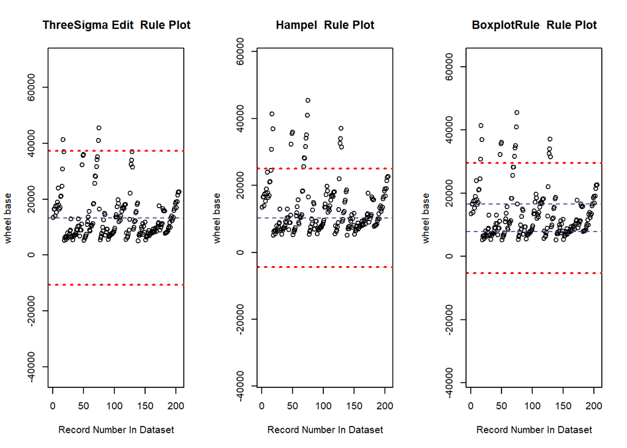

```
##          name totalOutliers lowerLimit upperLimit
## 1  ThreeSigma             3 -10689.846   37243.27
## 2      Hampel            18  -4409.427   24999.43
## 3 BoxplotRule            15  -5284.500   29575.50
```

```r
#building three sigma rule function
ThreeSigmaRule <- function(attribute,t=3) {
  meanAttribute <- mean(attribute, na.rm = TRUE)
  stdAttribute <- sd(attribute, na.rm = TRUE)
  unusualnessThreshold = t*stdAttribute
  upperLimit <- meanAttribute+unusualnessThreshold
  lowerLimit <- meanAttribute-unusualnessThreshold
  return (list(name="ThreeSigma Edit",attribute=attribute,upperLimit=upperLimit, lowerLimit=lowerLimit,typical = meanAttribute))
}

#building hampel identifier function
HampelIdentifier <- function(attribute, t = 3) {
  medianAttribute <- median(attribute, na.rm = TRUE)
  madAttribute <- mad(attribute, na.rm = TRUE)
  unusualnessThreshold = t*madAttribute
  upperLimit <- medianAttribute +unusualnessThreshold
  lowerLimit <- medianAttribute - unusualnessThreshold
  return(list(name="Hampel",attribute=attribute,upperLimit = upperLimit, lowerLimit = lowerLimit,typical = medianAttribute))
}

#building boxplot rule function
BoxplotRule <- function(attribute, t = 1.5) {
  Q1 <- quantile(attribute, na.rm = TRUE,probs=0.25,names=FALSE)
  Q3 <- quantile(attribute, na.rm = TRUE,probs=0.75,names=FALSE)
  IQR <- Q3-Q1
  unusualnessThreshold =t * IQR
  upperLimit <- Q3 + unusualnessThreshold
  lowerLimit <- Q1 - unusualnessThreshold
  return(list(name="BoxplotRule",attribute=attribute,upperLimit = upperLimit, lowerLimit = lowerLimit,typicalLower = Q1, typicalUpper=Q3))
}

#build outliers summary of each technique detection
summarizeDetail <- function(name,x, up,down){
  dataLabel <- rep("Normal", length(x))
  indexLowOutlier <- which(x < down)
  indexUpOutlier <- which(x > up)
  dataLabel[indexLowOutlier] <- "LowOutlier"
  dataLabel[indexUpOutlier] <- "UpOutlier"
  indexOutlier <- union(indexLowOutlier, indexUpOutlier)
  valuesOutlier <- x[indexOutlier]
  dataLabel <- dataLabel[indexOutlier]
  totalOutliers <- length(indexOutlier)

  return (
    list(
      name = name,
      totalOutliers = totalOutliers,
      upperLimit = up,
      lowerLimit = down,
      indexOutlier = indexOutlier,
      valuesOutlier = valuesOutlier,
      dataLabel = dataLabel
    )
  )
}

#build a function that represent all detection outliers result in a dataframe and plot for each technique in a one canvas.
detectOutliers <- function(attribute) {
  threeSigmaBound <- ThreeSigmaRule(attribute)
  HampelBound <- HampelIdentifier(attribute)
  boxplotBound <- BoxplotRule(attribute)

  plotDataList<-list(threeSigmaBound,HampelBound,boxplotBound)
  details <- list(summarizeDetail("ThreeSigma",attribute, threeSigmaBound$upperLimit, threeSigmaBound$lowerLimit),
               summarizeDetail("Hampel",attribute, HampelBound$upperLimit, HampelBound$lowerLimit),
               summarizeDetail("BoxplotRule",attribute, boxplotBound$upperLimit, boxplotBound$lowerLimit))

  summary<-data.frame()
  for(detail in details){
      summary <-rbind.data.frame(summary,data.frame(
          method = detail["name"],
          totalOutliers = detail["totalOutliers"],
          lowerLimit = detail["lowerLimit"],
          upperLimit = detail["upperLimit"]
      ))
  }

  par(mfrow=c(1,3))
  for(plotData in plotDataList){
    range=max(plotData$attribute)-min(plotData$attribute)
    ylimMin = min(c(plotData$attribute,plotData$lowerLimit-0.8*range))
    ylimMax = max(c(plotData$attribute,plotData$upperLimit+0.8*range))
    plot(plotData$attribute,
           xlab="Record Number In Dataset", ylab="wheel base",
           main = paste(plotData$name," Rule Plot"), ylim=c(ylimMin,ylimMax))
    if(plotData["name"]=="BoxplotRule"){
      abline(h = plotData$typicalUpper,lty="dashed", lwd=1, col="darkslateblue")
      abline(h = plotData$typicalLower,lty="dashed", lwd=1, col="darkslateblue")
    }else{
      abline(h = plotData$typical,lty="dashed", lwd=1, col="darkslateblue")
    }
    abline(h = plotData$upperLimit, lty="dotted", lwd=2, col="red")
    abline(h = plotData$lowerLimit, lty="dotted", lwd=2, col="red")
  }

  summary
}

detectOutliers(UpdateCarPriceDataFrame$Price)
```

The three-sigma detect 3 data points as outliers. Hampel identifier detect 18 data points as outliers. Boxplot rule detect 15 data points as outliers.

Remove any outliers in the price attribute detected by the boxplot rule

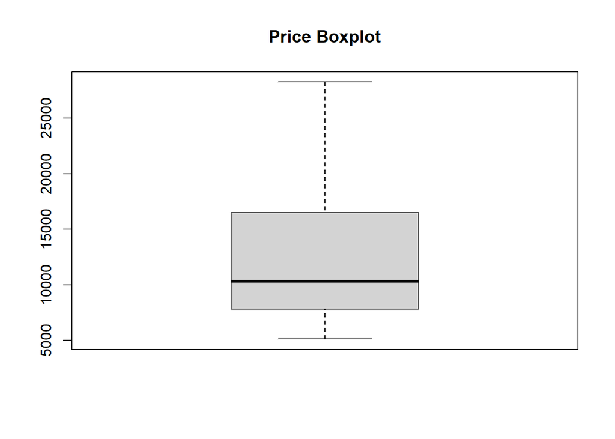

```r
x <- boxplot(UpdateCarPriceDataFrame$Price,outline=FALSE,main="Price Boxplot")
```

```r
print(x$out)
```

```
##  [1] 30760.0 41315.0 36880.0 32250.0 35550.0 36000.0 31600.0 34184.0 35056.0
## [10] 40960.0 45400.0 32528.0 34028.0 37028.0 31400.5
```

```r
outRm<-UpdateCarPriceDataFrame[!UpdateCarPriceDataFrame$Price %in% x$out,]
```

The outlier of price attribute has been removed.

#### Visualized relation between key variables

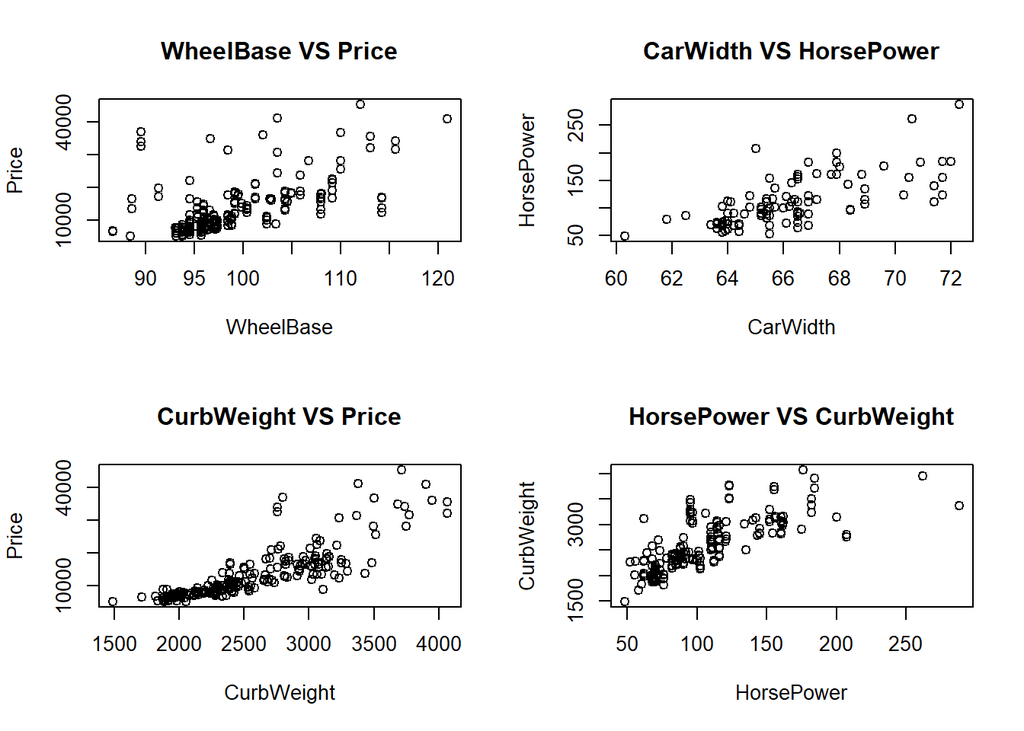

```r
canvas <- layout(matrix(c(1,2,3,4),nrow=2,byrow=TRUE))

plot(carPriceDataFrame$WheelBase,carPriceDataFrame$Price,main="WheelBase VS Price",xlab="WheelBase",ylab="Price")
plot(carPriceDataFrame$CarWidth,carPriceDataFrame$HorsePower,main="CarWidth VS HorsePower",xlab="CarWidth",ylab="HorsePower")
plot(carPriceDataFrame$CurbWeight,carPriceDataFrame$Price,main="CurbWeight VS Price",xlab="CurbWeight",ylab="Price")
plot(carPriceDataFrame$HorsePower,carPriceDataFrame$CurbWeight,main="HorsePower VS CurbWeight",xlab="HorsePower",ylab="CurbWeight")
```

From the output above, it reflect that curbweight and price variables are related. Horse power and curbweight variable also seems related.

### **DATA SPLITTING**

```r
library(caret)
set.seed(1)
#create training data set 70% for building model and testing set 30% for model evaluation
trainingIndex = createDataPartition(outRm$Price,p=0.7,list=FALSE)
testingSet = outRm[-trainingIndex, ]
trainingSet = outRm[trainingIndex, ]
cat("Testing Set Dimention data  : ",dim(testingSet),"\n")
```

```
## Testing Set Dimention data  :  56 12
```

```r
cat("Training Set Dimention data : ",dim(trainingSet))
```

```
## Training Set Dimention data :  134 12
```

### **DATA MODELLING**

```r
#Build summarize information from multiple models
summarizeModelMetric <- function(models, modelsSummaryRowNames) {
  summ = summary(model1)
  rse = sigma(model1)
  pvalue = pf(summary(model1)$fstatistic[1],summary(model1)$fstatistic[2],summary(model1)$fstatistic[3],lower.tail=FALSE)

  modelsSummary <- data.frame(matrix(ncol = 5, nrow = 0))
  colnames(modelsSummary) <-c("RSE", "FSTAT", "PVALUE", "R2", "ADJR2")
  for(model in models) {
    summ = summary(model)
    rse = sigma(model)
    pvalue = pf(summ$fstatistic[1],summ$fstatistic[2],summ$fstatistic[3],lower.tail=FALSE)
    modelsSummary[nrow(modelsSummary) + 1,] <- c(
      RSE = rse, FSTAT = summ$fstatistic["value"], PVALUE=pvalue, R2=summ["r.squared"], ADJR2=summ["adj.r.squared"])

  }

  rownames(modelsSummary)<-modelsSummaryRowNames

  return (modelsSummary)
}


#Build modeling function
modelingFunction <- function(formula, trainingData, testingData, isLogPrice = FALSE, isPrint=TRUE) {
  model1=lm(formula,trainingData)
  if (isPrint) print(summary(model1))
  if (isPrint) plot(model1)

  testingData$predicted <- predict(model1, testingData)
  if (isLogPrice == TRUE) {
    actualPrediction <- data.frame(testingData$Price, exp(testingData$predicted), testingData$Price - exp(testingData$predicted))
  } else {
    actualPrediction <- data.frame(testingData$Price, testingData$predicted, testingData$Price - testingData$predicted)
  }
  names(actualPrediction) <- c ("Price", "Predicted", "Residuals")
  if (isPrint) print(cor(actualPrediction))
  if (isPrint) print(head(actualPrediction,n=10))

  return (model1)
}
```

#### **DATA MODELLING - MODEL1**

I tried to model the dependent variables with all of the predictors variables

```r
#Model1
model1 = modelingFunction(Price~., trainingSet,testingSet)
```

```
##
## Call:
## lm(formula = formula, data = trainingData)
##
## Residuals:
##     Min      1Q  Median      3Q     Max
## -5058.3 -1320.1  -297.6  1184.5  6773.4
##
## Coefficients:
##                  Estimate Std. Error t value Pr(>|t|)
## (Intercept)    -52363.511  14169.075  -3.696 0.000330 ***
## Symboling        -283.245    218.315  -1.297 0.196935
## CarName           -18.568      4.879  -3.806 0.000222 ***
## FuelType        -1058.217   1146.452  -0.923 0.357810
## Aspiration        483.445    630.854   0.766 0.444958
## CarBody          -657.588    276.757  -2.376 0.019056 *
## WheelBase          20.701     88.292   0.234 0.815021
## CarWidth          782.095    232.117   3.369 0.001009 **
## CurbWeight          4.581      1.486   3.082 0.002539 **
## CylinderNumber    332.699    305.219   1.090 0.277847
## HorsePower         35.120     15.593   2.252 0.026092 *
## Citympg             7.571     67.421   0.112 0.910772
## ---
## Signif. codes:  0 '***' 0.001 '**' 0.01 '*' 0.05 '.' 0.1 ' ' 1
##
## Residual standard error: 2156 on 122 degrees of freedom
## Multiple R-squared:  0.836,  Adjusted R-squared:  0.8212
## F-statistic: 56.53 on 11 and 122 DF,  p-value: < 2.2e-16
```

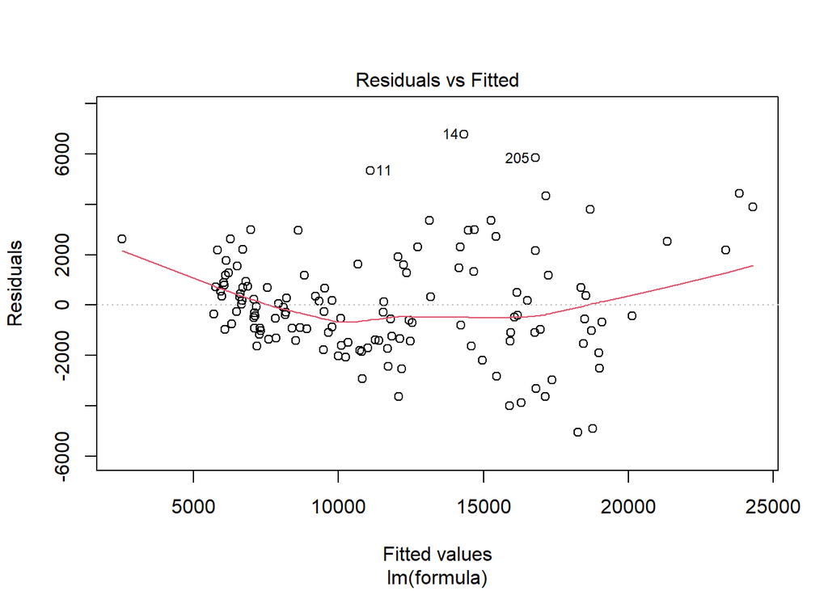

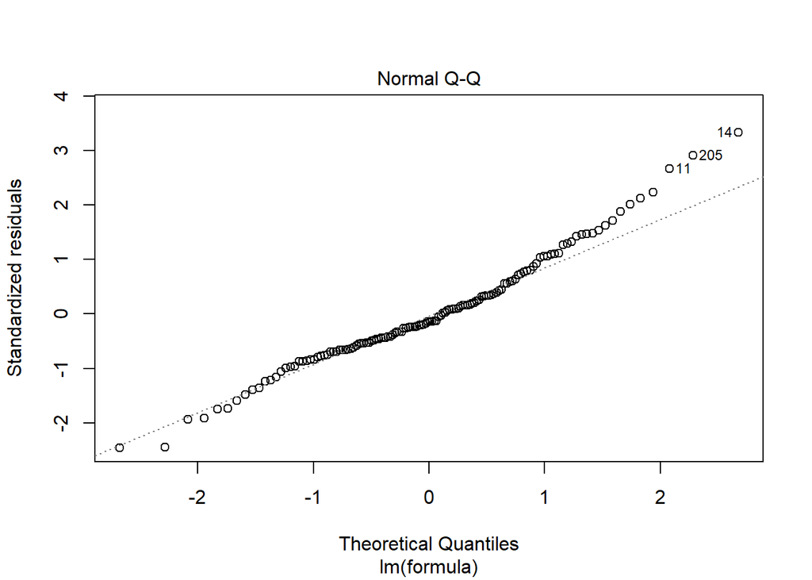

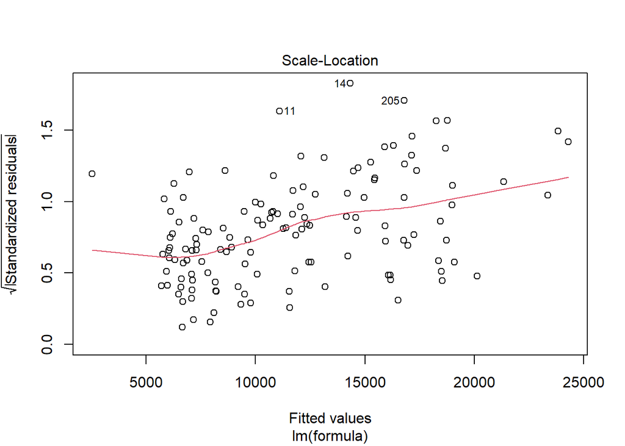

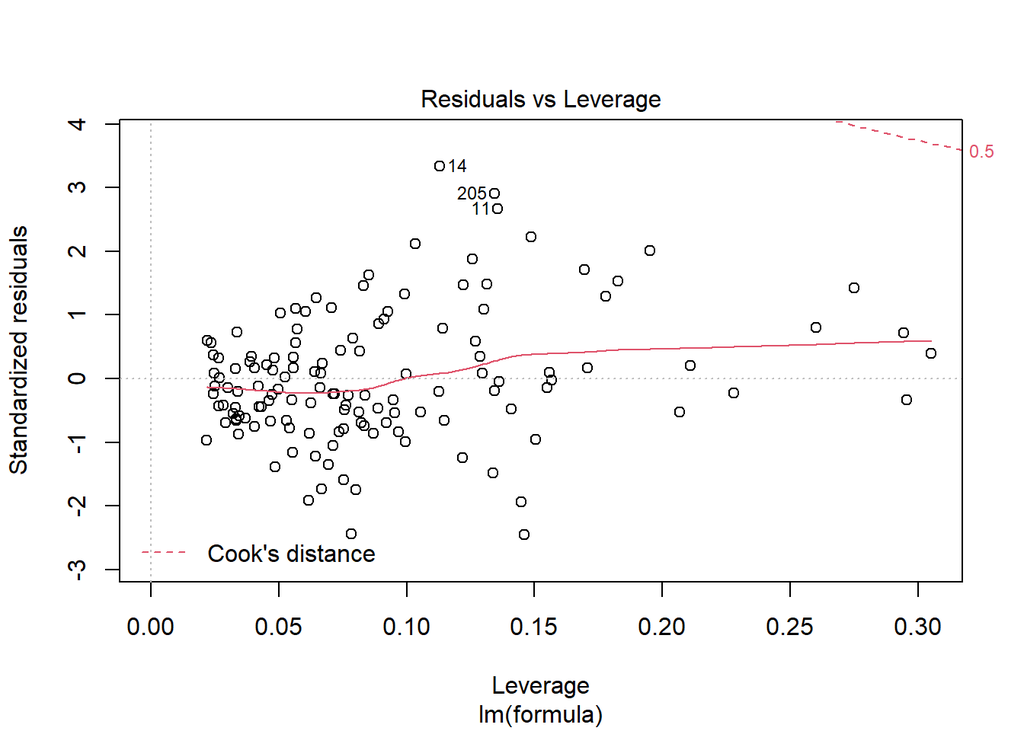

```
##               Price Predicted Residuals
## Price     1.0000000 0.8528653 0.6424202
## Predicted 0.8528653 1.0000000 0.1477615
## Residuals 0.6424202 0.1477615 1.0000000
##       Price Predicted  Residuals
## 1  16500.00 16709.917  -209.9172
## 2  15250.00 12716.137  2533.8630
## 3  17859.17 19922.038 -2062.8711
## 4  16925.00 11653.698  5271.3022
## 5  20970.00 14098.191  6871.8088
## 6  24565.00 17003.660  7561.3399
## 7   7609.00  7140.486   468.5144
## 8   8921.00 10931.737 -2010.7375
## 9  12964.00 16039.305 -3075.3045
## 10  5399.00  6825.928 -1426.9280
```

Then, we can improve the model performance above by checking each attribute correlation

```r
#check correlation
rcorr(as.matrix(trainingSet),type=c("pearson","spearman"))
```

```
##                Symboling CarName FuelType Aspiration CarBody WheelBase CarWidth
## Symboling           1.00   -0.24     0.18      -0.05   -0.61     -0.54    -0.30
## CarName            -0.24    1.00    -0.05       0.01    0.17      0.21     0.05
## FuelType            0.18   -0.05     1.00      -0.39   -0.17     -0.37    -0.33
## Aspiration         -0.05    0.01    -0.39       1.00    0.05      0.31     0.40
## CarBody            -0.61    0.17    -0.17       0.05    1.00      0.46     0.27
## WheelBase          -0.54    0.21    -0.37       0.31    0.46      1.00     0.83
## CarWidth           -0.30    0.05    -0.33       0.40    0.27      0.83     1.00
## CurbWeight         -0.30    0.14    -0.32       0.46    0.24      0.82     0.87
## CylinderNumber      0.20    0.05     0.13      -0.16   -0.11     -0.14    -0.15
## HorsePower          0.00    0.06     0.15       0.46   -0.04      0.39     0.58
## Citympg            -0.01   -0.05    -0.24      -0.30   -0.03     -0.48    -0.61
## Price              -0.20   -0.05    -0.28       0.48    0.10      0.69     0.83
##                CurbWeight CylinderNumber HorsePower Citympg Price
## Symboling           -0.30           0.20       0.00   -0.01 -0.20
## CarName              0.14           0.05       0.06   -0.05 -0.05
## FuelType            -0.32           0.13       0.15   -0.24 -0.28
## Aspiration           0.46          -0.16       0.46   -0.30  0.48
## CarBody              0.24          -0.11      -0.04   -0.03  0.10
## WheelBase            0.82          -0.14       0.39   -0.48  0.69
## CarWidth             0.87          -0.15       0.58   -0.61  0.83
## CurbWeight           1.00          -0.03       0.73   -0.72  0.87
## CylinderNumber      -0.03           1.00       0.16   -0.16 -0.01
## HorsePower           0.73           0.16       1.00   -0.81  0.71
## Citympg             -0.72          -0.16      -0.81    1.00 -0.66
## Price                0.87          -0.01       0.71   -0.66  1.00
##
## n= 134
##
##
## P
##                Symboling CarName FuelType Aspiration CarBody WheelBase CarWidth
## Symboling                0.0055  0.0388   0.5578     0.0000  0.0000    0.0005
## CarName        0.0055            0.5644   0.9269     0.0452  0.0136    0.5410
## FuelType       0.0388    0.5644           0.0000     0.0544  0.0000    0.0000
## Aspiration     0.5578    0.9269  0.0000              0.5310  0.0003    0.0000
## CarBody        0.0000    0.0452  0.0544   0.5310             0.0000    0.0014
## WheelBase      0.0000    0.0136  0.0000   0.0003     0.0000            0.0000
## CarWidth       0.0005    0.5410  0.0000   0.0000     0.0014  0.0000
## CurbWeight     0.0005    0.1123  0.0001   0.0000     0.0048  0.0000    0.0000
## CylinderNumber 0.0191    0.5641  0.1214   0.0733     0.2190  0.1186    0.0928
## HorsePower     0.9988    0.5037  0.0784   0.0000     0.6569  0.0000    0.0000
## Citympg        0.9163    0.5933  0.0061   0.0005     0.7718  0.0000    0.0000
## Price          0.0199    0.5413  0.0010   0.0000     0.2493  0.0000    0.0000
##                CurbWeight CylinderNumber HorsePower Citympg Price
## Symboling      0.0005     0.0191         0.9988     0.9163  0.0199
## CarName        0.1123     0.5641         0.5037     0.5933  0.5413
## FuelType       0.0001     0.1214         0.0784     0.0061  0.0010
## Aspiration     0.0000     0.0733         0.0000     0.0005  0.0000
## CarBody        0.0048     0.2190         0.6569     0.7718  0.2493
## WheelBase      0.0000     0.1186         0.0000     0.0000  0.0000
## CarWidth       0.0000     0.0928         0.0000     0.0000  0.0000
## CurbWeight                0.7177         0.0000     0.0000  0.0000
## CylinderNumber 0.7177                    0.0577     0.0582  0.9486
## HorsePower     0.0000     0.0577                    0.0000  0.0000
## Citympg        0.0000     0.0582         0.0000             0.0000
## Price          0.0000     0.9486         0.0000     0.0000
```

```r
cleanTrainingSet = trainingSet[-c(1:5,9)]
cleanTestingSet = testingSet[-c(1:5,9)]
rcorr(as.matrix(cleanTrainingSet),type=c("pearson","spearman"))
```

```
##            WheelBase CarWidth CurbWeight HorsePower Citympg Price
## WheelBase       1.00     0.83       0.82       0.39   -0.48  0.69
## CarWidth        0.83     1.00       0.87       0.58   -0.61  0.83
## CurbWeight      0.82     0.87       1.00       0.73   -0.72  0.87
## HorsePower      0.39     0.58       0.73       1.00   -0.81  0.71
## Citympg        -0.48    -0.61      -0.72      -0.81    1.00 -0.66
## Price           0.69     0.83       0.87       0.71   -0.66  1.00
##
## n= 134
##
##
## P
##            WheelBase CarWidth CurbWeight HorsePower Citympg Price
## WheelBase             0        0          0          0       0
## CarWidth    0                  0          0          0       0
## CurbWeight  0         0                   0          0       0
## HorsePower  0         0        0                     0       0
## Citympg     0         0        0          0                  0
## Price       0         0        0          0          0
```

#### **DATA MODELLING - MODEL2**

Then I tried to build model2 using the clean training data

```r
#Model2
model2=modelingFunction(Price~., cleanTrainingSet,cleanTestingSet)
```

```
##
## Call:
## lm(formula = formula, data = trainingData)
##
## Residuals:
##     Min      1Q  Median      3Q     Max
## -4076.8 -1347.7  -321.8   605.7  8595.0
##
## Coefficients:
##               Estimate Std. Error t value Pr(>|t|)
## (Intercept) -61837.608  12408.912  -4.983 1.98e-06 ***
## WheelBase      -87.334     78.849  -1.108   0.2701
## CarWidth       964.019    229.381   4.203 4.91e-05 ***
## CurbWeight       5.592      1.250   4.473 1.68e-05 ***
## HorsePower      34.460     13.233   2.604   0.0103 *
## Citympg         51.646     54.865   0.941   0.3483
## ---
## Signif. codes:  0 '***' 0.001 '**' 0.01 '*' 0.05 '.' 0.1 ' ' 1
##
## Residual standard error: 2307 on 128 degrees of freedom
## Multiple R-squared:  0.8029, Adjusted R-squared:  0.7953
## F-statistic: 104.3 on 5 and 128 DF,  p-value: < 2.2e-16
```

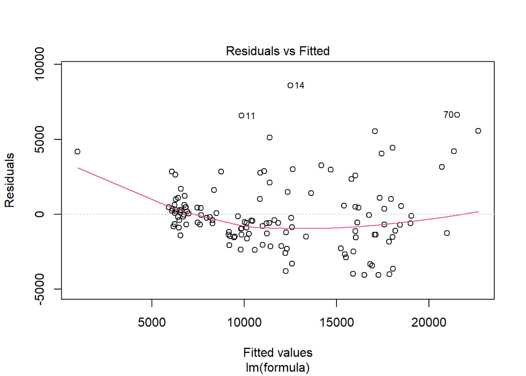

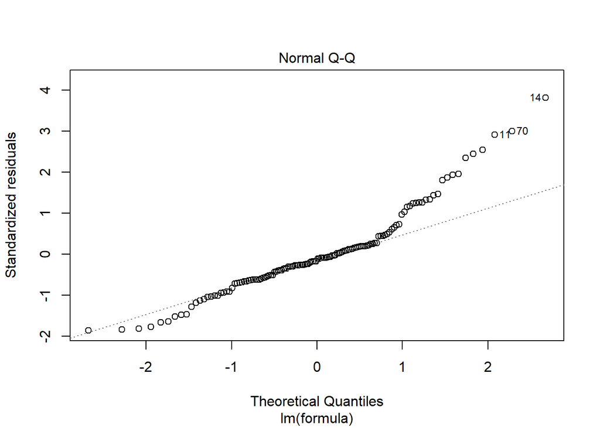

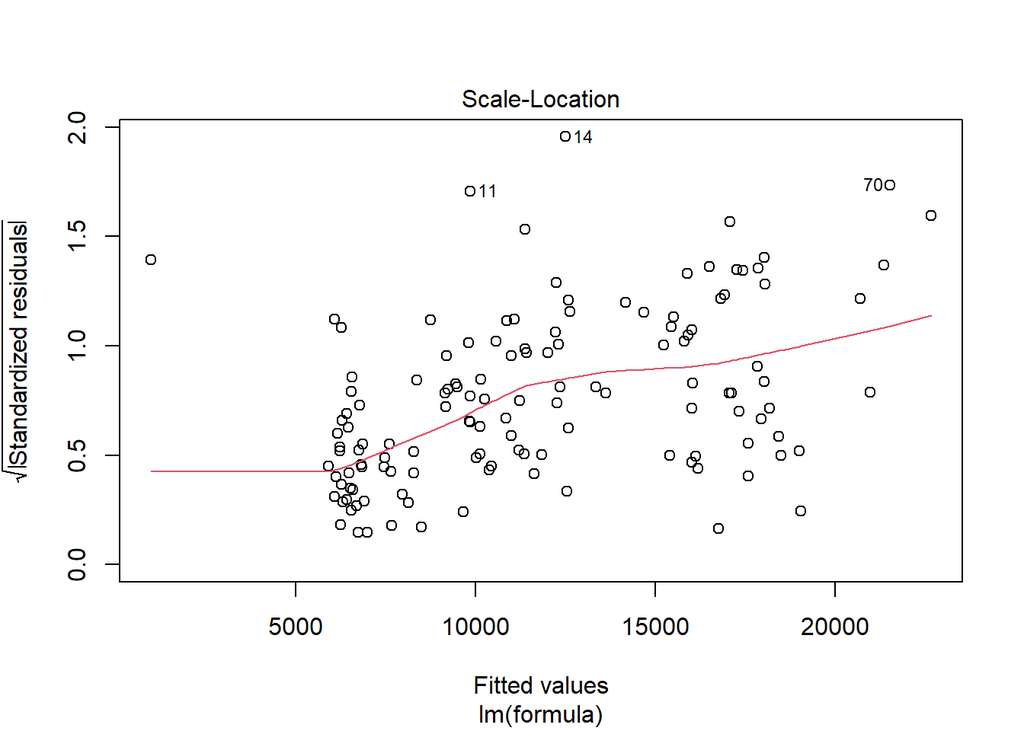

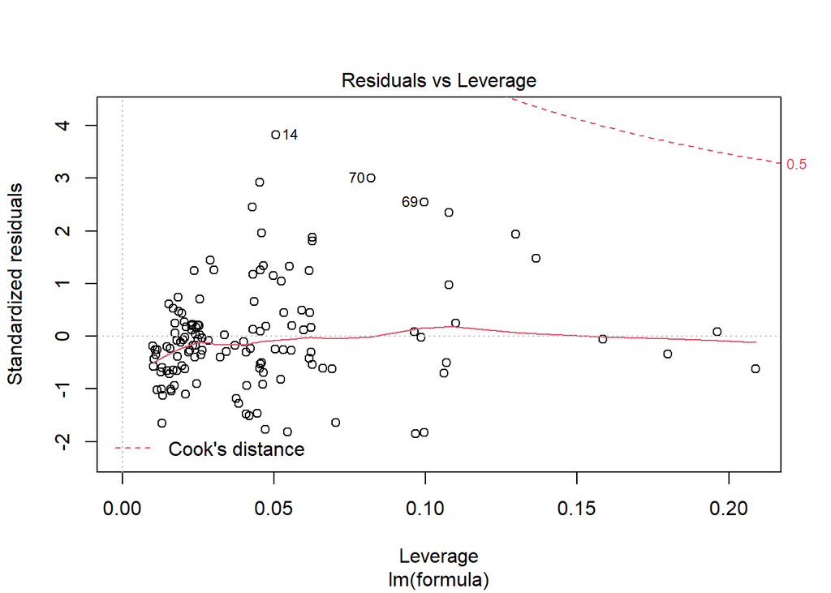

```
##               Price  Predicted  Residuals
## Price     1.0000000 0.81783272 0.64587025
## Predicted 0.8178327 1.00000000 0.08888353
## Residuals 0.6458702 0.08888353 1.00000000
##       Price Predicted  Residuals
## 1  16500.00 15128.143  1371.8571
## 2  15250.00 12153.042  3096.9581
## 3  17859.17 18343.205  -484.0375
## 4  16925.00  9854.837  7070.1628
## 5  20970.00 12202.366  8767.6345
## 6  24565.00 15903.690  8661.3095
## 7   7609.00  6551.281  1057.7194
## 8   8921.00  9865.247  -944.2469
## 9  12964.00 15399.843 -2435.8432
## 10  5399.00  5979.874  -580.8741
```

If I check the normality, it can be seen that the dependent variables doesn’t normally distributed(bell-shape).

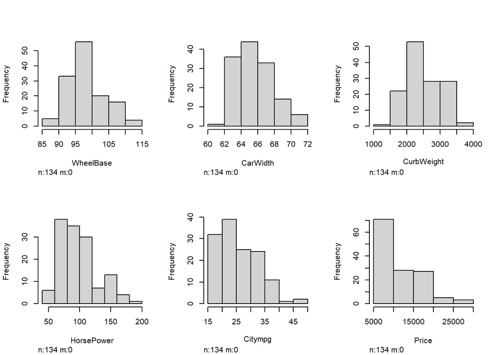

```r
#check normality
hist.data.frame(cleanTrainingSet)
```

So, I tried to do optimization by using log() function to the dependent variable (Price)

#### **DATA MODELLING - MODEL3**

In the next model,I use the natural log to the price variable in the training data using log() and see the change in performance of the model.

```r
logPriceTrainingSet=cleanTrainingSet
logPriceTrainingSet$Price = log(logPriceTrainingSet$Price)
#Model3
model3= modelingFunction(Price~., logPriceTrainingSet,cleanTestingSet, isLogPrice = TRUE)
```

```
##
## Call:
## lm(formula = formula, data = trainingData)
##
## Residuals:
##      Min       1Q   Median       3Q      Max
## -0.32204 -0.10724 -0.01446  0.07521  0.56043
##
## Coefficients:
##               Estimate Std. Error t value Pr(>|t|)
## (Intercept)  4.4967779  0.8734057   5.149 9.64e-07 ***
## WheelBase   -0.0064341  0.0055499  -1.159 0.248481
## CarWidth     0.0617254  0.0161451   3.823 0.000205 ***
## CurbWeight   0.0004732  0.0000880   5.377 3.46e-07 ***
## HorsePower   0.0024948  0.0009314   2.679 0.008366 **
## Citympg     -0.0028047  0.0038617  -0.726 0.468990
## ---
## Signif. codes:  0 '***' 0.001 '**' 0.01 '*' 0.05 '.' 0.1 ' ' 1
##
## Residual standard error: 0.1624 on 128 degrees of freedom
## Multiple R-squared:  0.8511, Adjusted R-squared:  0.8453
## F-statistic: 146.4 on 5 and 128 DF,  p-value: < 2.2e-16
```

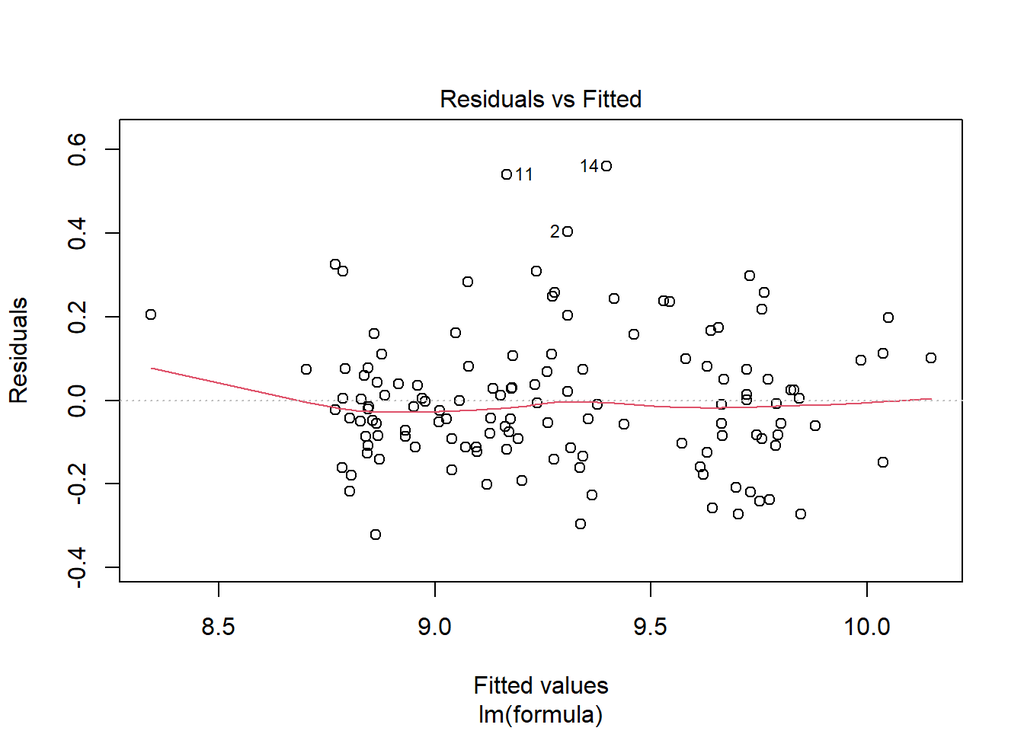

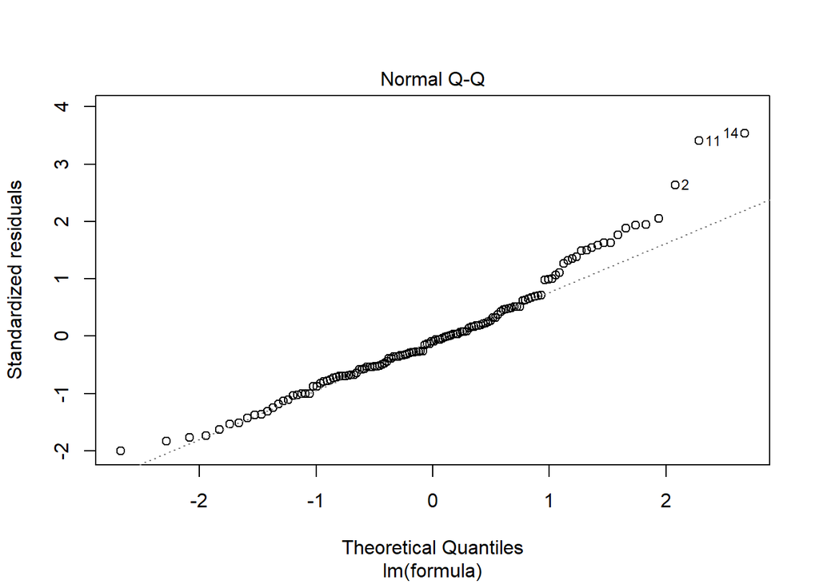

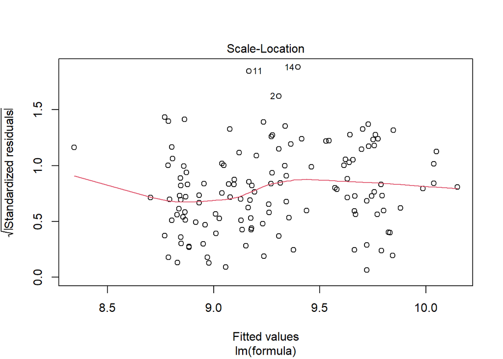

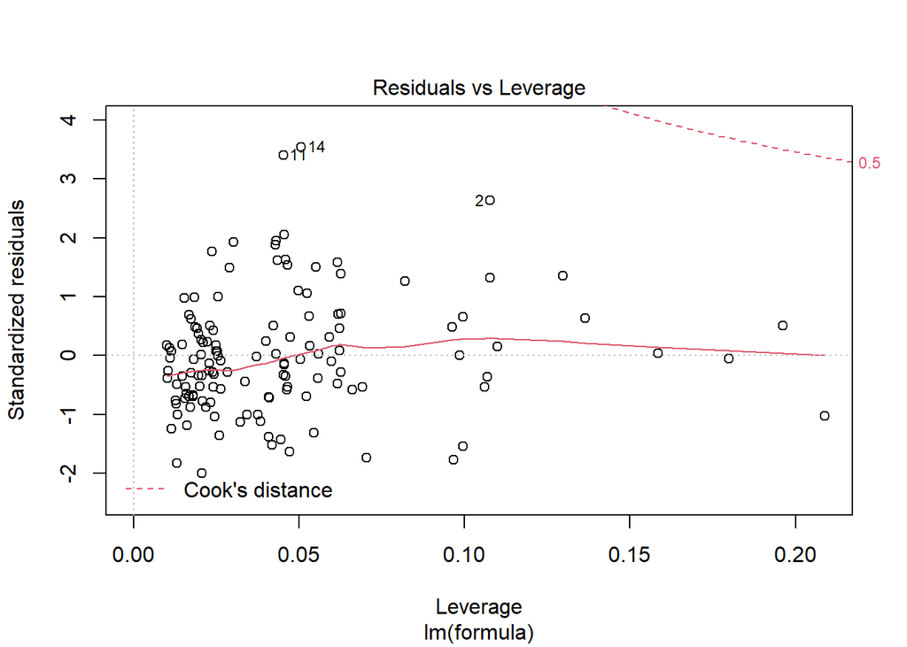

```
##               Price Predicted Residuals
## Price     1.0000000 0.8135376 0.6977627
## Predicted 0.8135376 1.0000000 0.1511021
## Residuals 0.6977627 0.1511021 1.0000000
##       Price Predicted  Residuals
## 1  16500.00 14743.175  1756.8250
## 2  15250.00 11550.822  3699.1782
## 3  17859.17 18896.384 -1037.2165
## 4  16925.00  9568.630  7356.3696
## 5  20970.00 11740.620  9229.3802
## 6  24565.00 15548.121  9016.8794
## 7   7609.00  7015.584   593.4159
## 8   8921.00  9618.084  -697.0844
## 9  12964.00 14924.756 -1960.7560
## 10  5399.00  6353.215  -954.2150
```

Here, I also check the linearity between each independent variables to the dependent variable

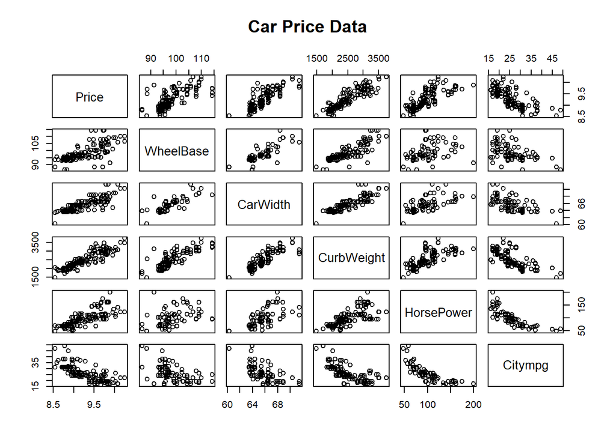

```r
pairs(~ Price+WheelBase+CarWidth+CurbWeight+HorsePower+Citympg, data=logPriceTrainingSet, main = "Car Price Data")
```

CurbWeight and HorsePower are good linear variables.

#### **DATA MODELLING - MODEL4**

Then I try to fit the dependent variable with CurbWeight and HorsePower variables in model4

```r
#Model4
model4 = modelingFunction(Price~CurbWeight+HorsePower, cleanTrainingSet,cleanTestingSet)
```

```
##
## Call:
## lm(formula = formula, data = trainingData)
##
## Residuals:
##     Min      1Q  Median      3Q     Max
## -5094.0 -1231.0  -280.0   862.5  7918.8
##
## Coefficients:
##               Estimate Std. Error t value Pr(>|t|)
## (Intercept) -1.102e+04  1.141e+03  -9.662  < 2e-16 ***
## CurbWeight   7.963e+00  6.415e-01  12.413  < 2e-16 ***
## HorsePower   2.806e+01  9.900e+00   2.834  0.00532 **
## ---
## Signif. codes:  0 '***' 0.001 '**' 0.01 '*' 0.05 '.' 0.1 ' ' 1
##
## Residual standard error: 2440 on 131 degrees of freedom
## Multiple R-squared:  0.7744, Adjusted R-squared:  0.771
## F-statistic: 224.9 on 2 and 131 DF,  p-value: < 2.2e-16
```

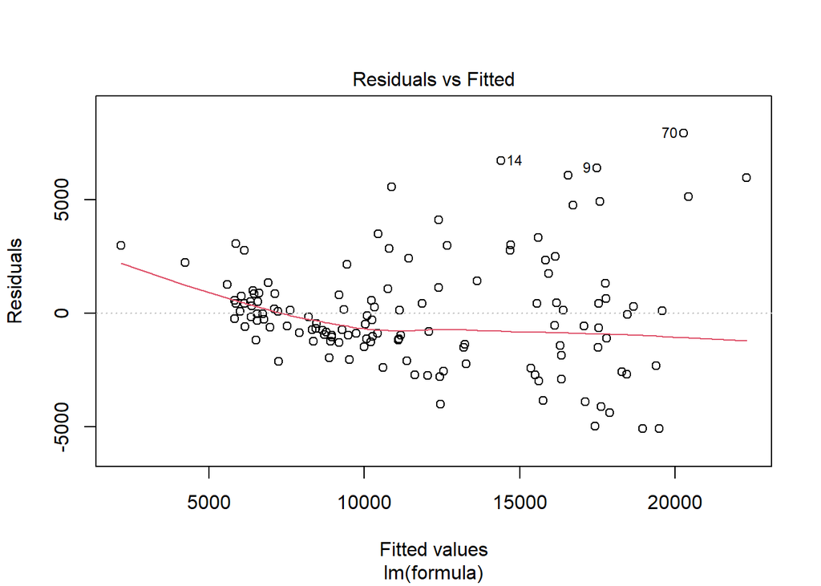

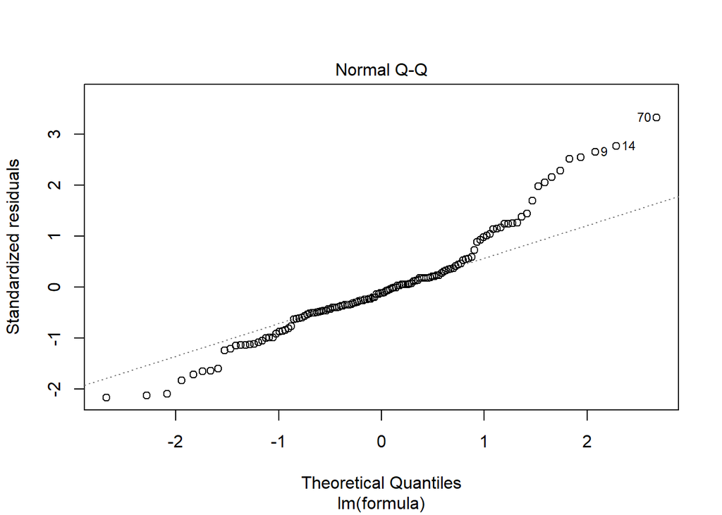

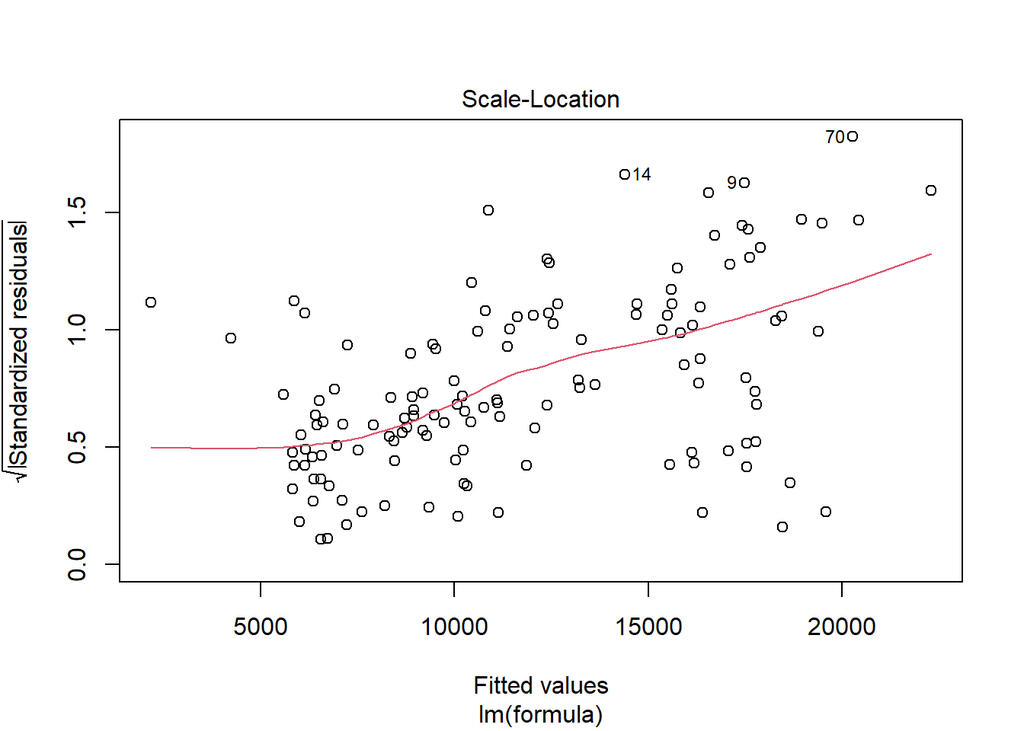

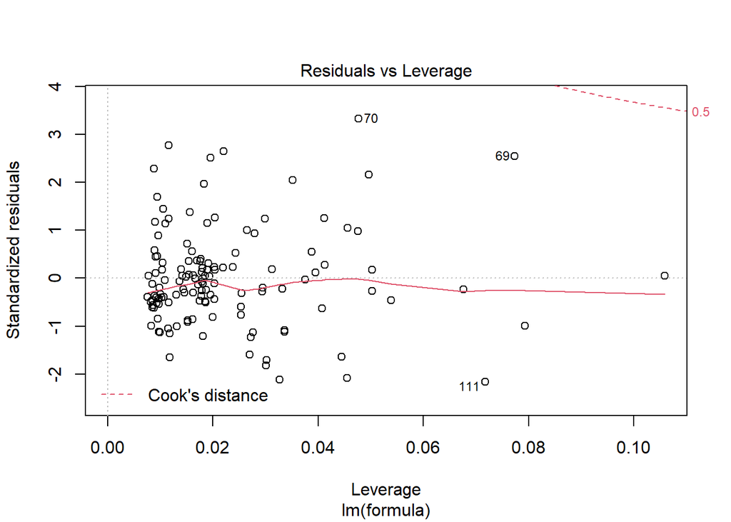

```
##               Price Predicted Residuals
## Price     1.0000000 0.8283280 0.6803671
## Predicted 0.8283280 1.0000000 0.1529807
## Residuals 0.6803671 0.1529807 1.0000000
##       Price Predicted   Residuals
## 1  16500.00 15776.262   723.73817
## 2  15250.00 12025.511  3224.48931
## 3  17859.17 17775.994    83.17287
## 4  16925.00 10881.178  6043.82202
## 5  20970.00 13950.550  7019.44980
## 6  24565.00 16697.617  7867.38251
## 7   7609.00  6722.450   886.55023
## 8   8921.00 11631.163 -2710.16270
## 9  12964.00 15428.181 -2464.18051
## 10  5399.00  5287.676   111.32448
```

#### **DATA MODELLING - MODEL5**

Then below in model5, I use the natural log to the price variable and fit it with CurbWeight and HorsePower variables in the training data and see the change in performance of the model

```r
logcleanTrainingSet = cleanTrainingSet
logcleanTrainingSet$Price = log(logcleanTrainingSet$Price)
logcleanTestingSet = cleanTestingSet
model5= modelingFunction(Price~CurbWeight+HorsePower, logcleanTrainingSet,logcleanTestingSet, isLogPrice = TRUE)
```

```
##
## Call:
## lm(formula = formula, data = trainingData)
##
## Residuals:
##      Min       1Q   Median       3Q      Max
## -0.36564 -0.10268 -0.02748  0.09155  0.49042
##
## Coefficients:
##              Estimate Std. Error t value Pr(>|t|)
## (Intercept) 7.393e+00  7.953e-02  92.964  < 2e-16 ***
## CurbWeight  6.371e-04  4.472e-05  14.247  < 2e-16 ***
## HorsePower  2.942e-03  6.902e-04   4.263 3.83e-05 ***
## ---
## Signif. codes:  0 '***' 0.001 '**' 0.01 '*' 0.05 '.' 0.1 ' ' 1
##
## Residual standard error: 0.1701 on 131 degrees of freedom
## Multiple R-squared:  0.8328, Adjusted R-squared:  0.8303
## F-statistic: 326.3 on 2 and 131 DF,  p-value: < 2.2e-16
```

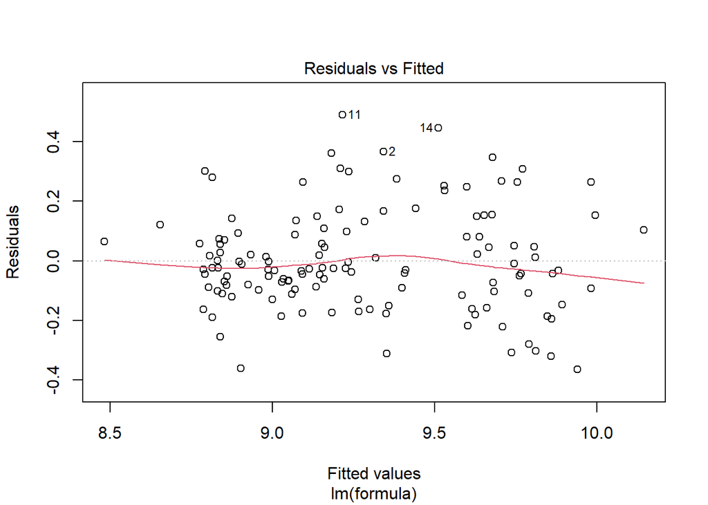

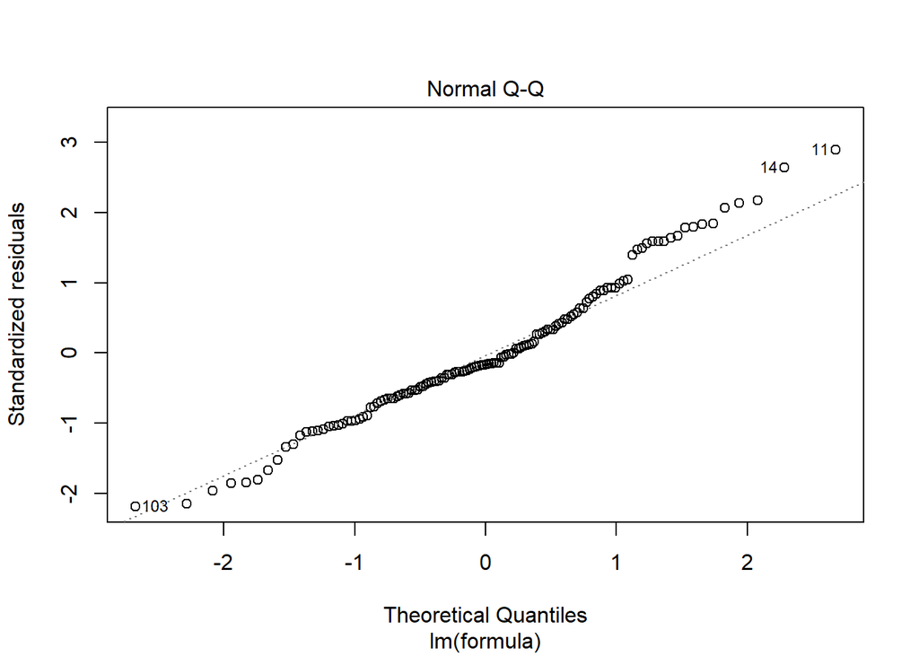

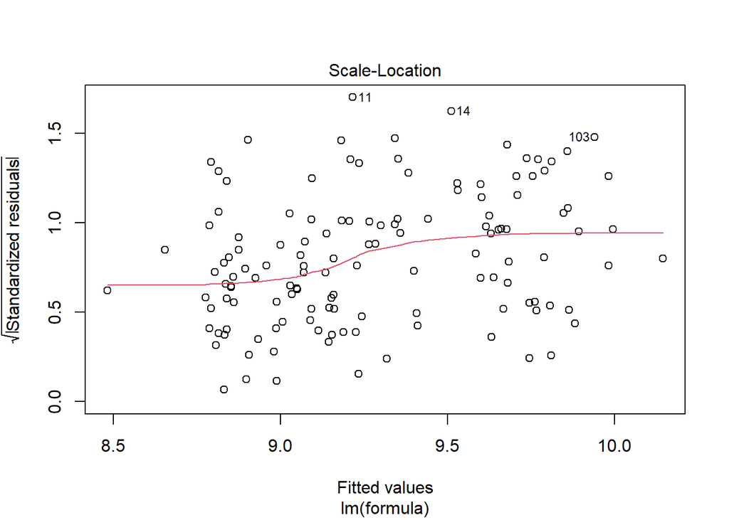

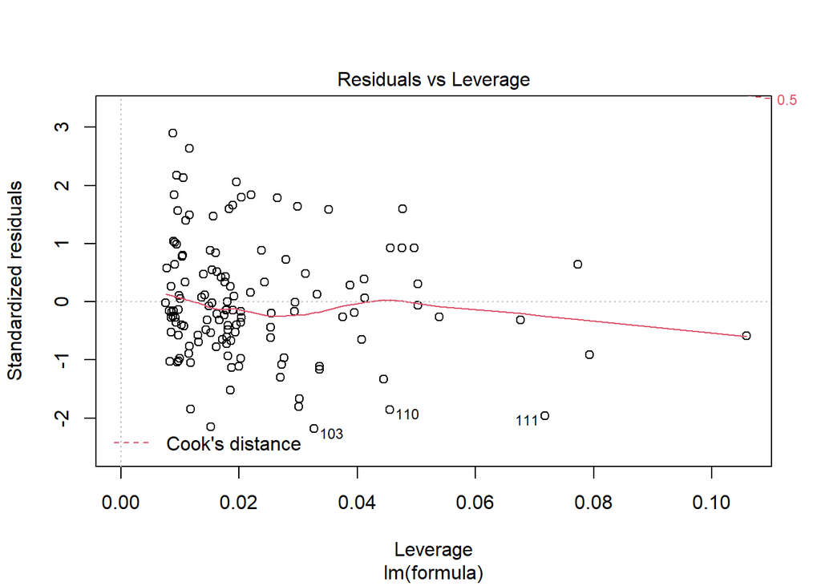

```
##               Price Predicted Residuals
## Price     1.0000000 0.8214954 0.7277219
## Predicted 0.8214954 1.0000000 0.2067255
## Residuals 0.7277219 0.2067255 1.0000000
##       Price Predicted  Residuals
## 1  16500.00 15445.577  1054.4226
## 2  15250.00 11095.419  4154.5811
## 3  17859.17 18201.714  -342.5470
## 4  16925.00 10061.275  6863.7252
## 5  20970.00 13042.770  7927.2300
## 6  24565.00 16249.199  8315.8015
## 7   7609.00  7049.285   559.7149
## 8   8921.00 10587.173 -1666.1730
## 9  12964.00 14927.382 -1963.3815
## 10  5399.00  6249.771  -850.7709
```

The output of this model5 shows that the F-statistics is increased to 326.3 and the predictor has highly significant p values. This model is better than previous model(model4).

#### **DATA MODELLING - MODEL6**

Then below in model6, I use the natural log to the price variable and fit it with HorsePower variables in the training data and see the change in performance of the model

```r
logcleanTrainingSet = cleanTrainingSet
logcleanTrainingSet$Price = log(logcleanTrainingSet$Price)
logcleanTestingSet = cleanTestingSet
model6 = modelingFunction(Price~HorsePower, logcleanTrainingSet,logcleanTestingSet, isLogPrice = TRUE)
```

```
##
## Call:
## lm(formula = formula, data = trainingData)
##
## Residuals:
##      Min       1Q   Median       3Q      Max
## -0.44168 -0.19724 -0.06821  0.16024  0.72259
##
## Coefficients:
##              Estimate Std. Error t value Pr(>|t|)
## (Intercept) 8.2871062  0.0777570  106.58   <2e-16 ***
## HorsePower  0.0100738  0.0007558   13.33   <2e-16 ***
## ---
## Signif. codes:  0 '***' 0.001 '**' 0.01 '*' 0.05 '.' 0.1 ' ' 1
##
## Residual standard error: 0.2706 on 132 degrees of freedom
## Multiple R-squared:  0.5737, Adjusted R-squared:  0.5705
## F-statistic: 177.7 on 1 and 132 DF,  p-value: < 2.2e-16
```

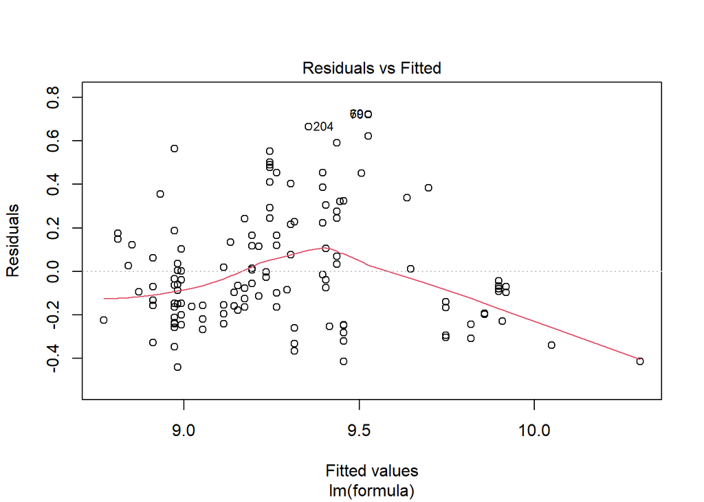

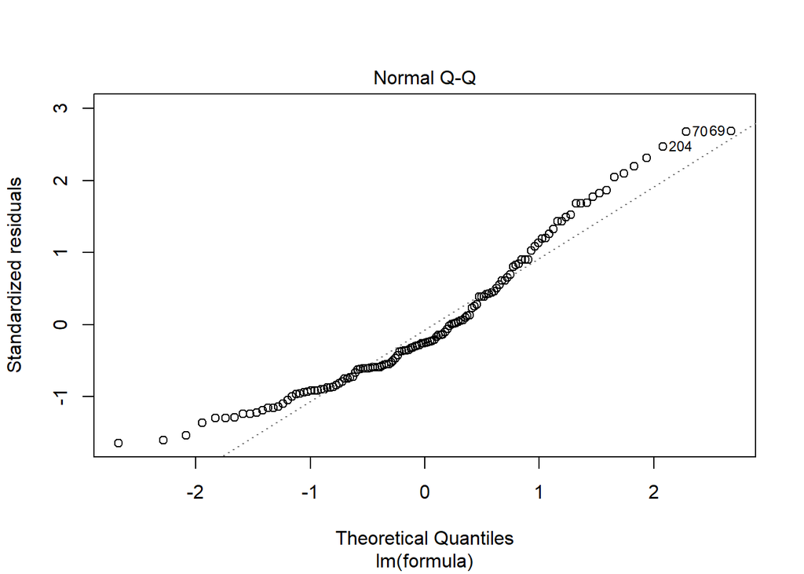

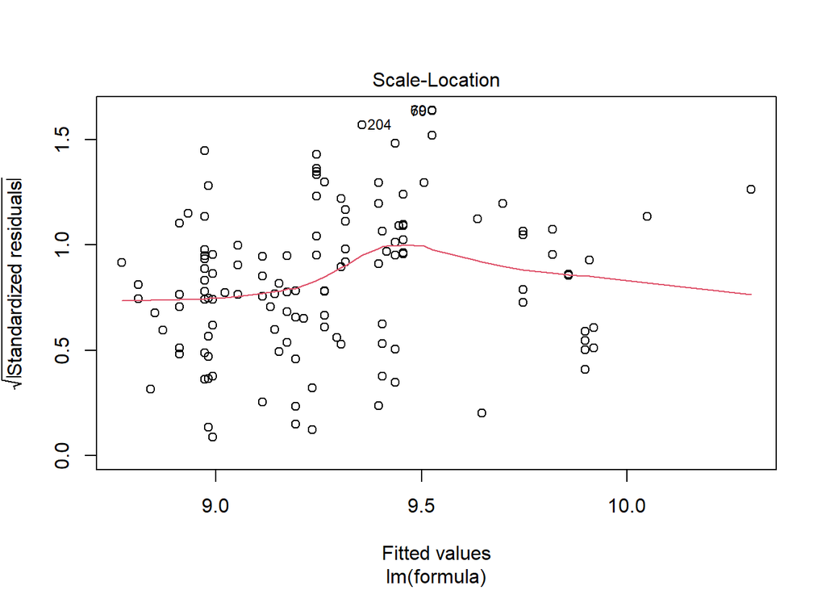

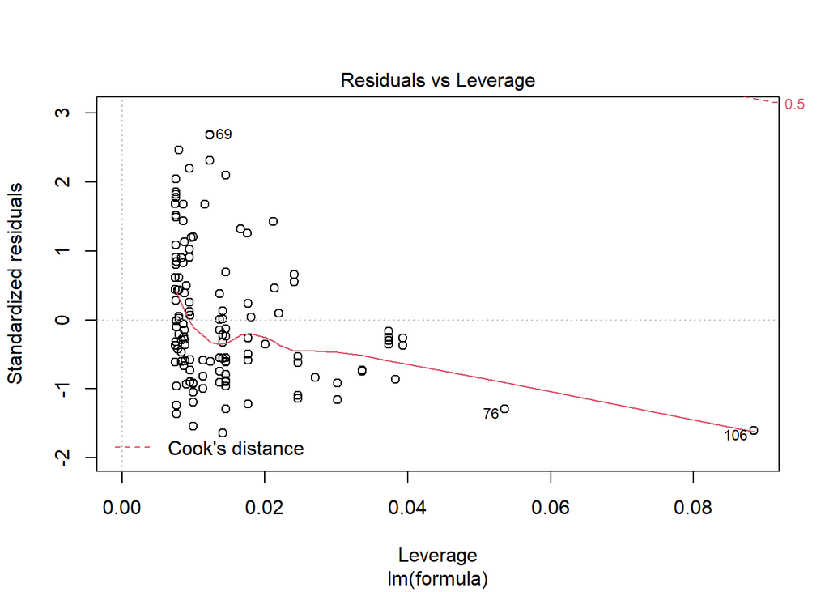

```
##               Price    Predicted    Residuals
## Price     1.0000000  0.738346714  0.668939855
## Predicted 0.7383467  1.000000000 -0.007398981
## Residuals 0.6689399 -0.007398981  1.000000000
##       Price Predicted  Residuals
## 1  16500.00 18741.059 -2241.0595
## 2  15250.00 12030.793  3219.2073
## 3  17859.17 19908.756 -2049.5891
## 4  16925.00 10988.016  5936.9845
## 5  20970.00 13440.617  7529.3826
## 6  24565.00 13440.617 11124.3826
## 7   7609.00  7880.329  -271.3289
## 8   8921.00  9639.273  -718.2733
## 9  12964.00 17116.665 -4152.6654
## 10  5399.00  7270.167 -1871.1666
```

The output of this model6 shows that the F-statistics is decreased to 177.7. This model6 is become worse.

#### **THE BEST DATA MODEL RESULT & EVALUATION**

Below I build function to see the comparison between all models that I have made above easily.

```r
summarizeModelMetric(list(model1, model2, model3, model4, model5, model6),
                     list("Model1 = Price~.", "Model2 = Price~WheelBase+CarWidth+CurbWeight+HorsePower+Citympg","Model3 = log(Price) ~.","Model4 = Price~CurbWeight+HorsePower","Model5 = log(Price)~CurbWeight+HorsePower","Model6 = log(Price)~Horsepower"))
```

```
##                                                                          RSE
## Model1 = Price~.                                                2155.9328230
## Model2 = Price~WheelBase+CarWidth+CurbWeight+HorsePower+Citympg 2306.9837107
## Model3 = log(Price) ~.                                             0.1623779
## Model4 = Price~CurbWeight+HorsePower                            2439.9546807
## Model5 = log(Price)~CurbWeight+HorsePower                          0.1700958
## Model6 = log(Price)~Horsepower                                     0.2705630
##                                                                     FSTAT
## Model1 = Price~.                                                 56.52597
## Model2 = Price~WheelBase+CarWidth+CurbWeight+HorsePower+Citympg 104.31496
## Model3 = log(Price) ~.                                          146.35355
## Model4 = Price~CurbWeight+HorsePower                            224.85193
## Model5 = log(Price)~CurbWeight+HorsePower                       326.25800
## Model6 = log(Price)~Horsepower                                  177.66933
##                                                                       PVALUE
## Model1 = Price~.                                                1.467672e-42
## Model2 = Price~WheelBase+CarWidth+CurbWeight+HorsePower+Citympg 2.045904e-43
## Model3 = log(Price) ~.                                          3.597578e-51
## Model4 = Price~CurbWeight+HorsePower                            4.387689e-43
## Model5 = log(Price)~CurbWeight+HorsePower                       1.321704e-51
## Model6 = log(Price)~Horsepower                                  3.293794e-26
##                                                                        R2
## Model1 = Price~.                                                0.8359742
## Model2 = Price~WheelBase+CarWidth+CurbWeight+HorsePower+Citympg 0.8029480
## Model3 = log(Price) ~.                                          0.8511226
## Model4 = Price~CurbWeight+HorsePower                            0.7744117
## Model5 = log(Price)~CurbWeight+HorsePower                       0.8328049
## Model6 = log(Price)~Horsepower                                  0.5737389
##                                                                     ADJR2
## Model1 = Price~.                                                0.8211850
## Model2 = Price~WheelBase+CarWidth+CurbWeight+HorsePower+Citympg 0.7952507
## Model3 = log(Price) ~.                                          0.8453071
## Model4 = Price~CurbWeight+HorsePower                            0.7709676
## Model5 = log(Price)~CurbWeight+HorsePower                       0.8302524
## Model6 = log(Price)~Horsepower                                  0.5705096
```

From the output above, I choose `Model5` as the best fit because it has small Residual std.Error value, highest F-stat value, lowest P-value, and high adjusted R-squared value.

#### Best model result and interpretation

```r
finalModel = model5
testingSet$predicted <- predict(finalModel, testingSet)
summary(finalModel)
```

```
##
## Call:
## lm(formula = formula, data = trainingData)
##
## Residuals:
##      Min       1Q   Median       3Q      Max
## -0.36564 -0.10268 -0.02748  0.09155  0.49042
##
## Coefficients:
##              Estimate Std. Error t value Pr(>|t|)
## (Intercept) 7.393e+00  7.953e-02  92.964  < 2e-16 ***
## CurbWeight  6.371e-04  4.472e-05  14.247  < 2e-16 ***
## HorsePower  2.942e-03  6.902e-04   4.263 3.83e-05 ***
## ---
## Signif. codes:  0 '***' 0.001 '**' 0.01 '*' 0.05 '.' 0.1 ' ' 1
##
## Residual standard error: 0.1701 on 131 degrees of freedom
## Multiple R-squared:  0.8328, Adjusted R-squared:  0.8303
## F-statistic: 326.3 on 2 and 131 DF,  p-value: < 2.2e-16
```

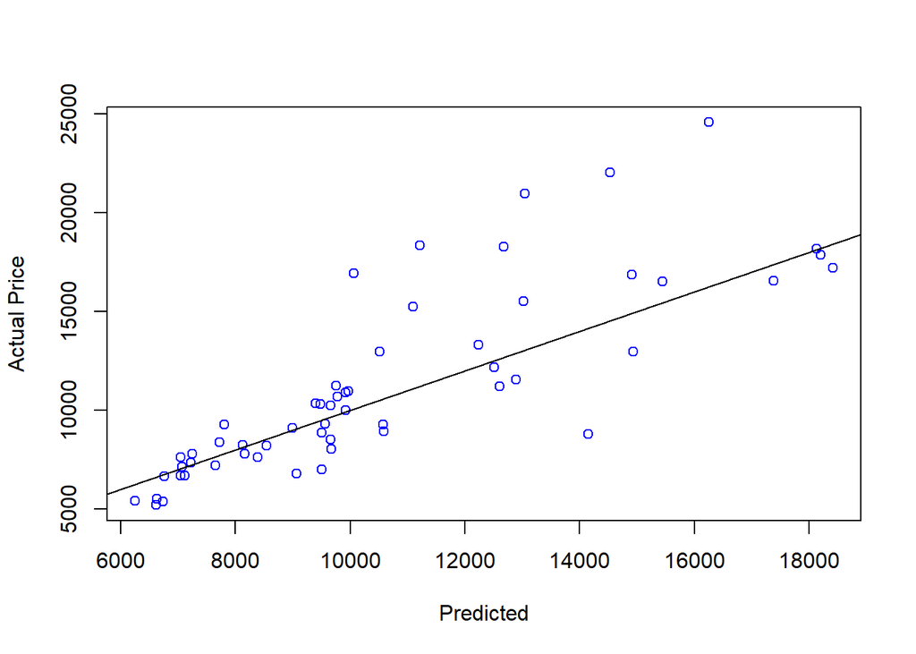

```
__Explanation:__
From the output above, I choose Model5 as the best fit because it has small Residual standard error value, highest F-stat value, lowest P-value, and high adjusted R-squared value.

To see whether our model is good or not, we can see from:
1. The higher adjusted R-squared value means the more significant the independent variable to be use for prediction the dependent variable.
2. The smaller residual standard error means the prediction are more better.
3. The higher the F-stat, the prediction are better.
4. The lower the p-value, the prediction are better.

From the summary of my final model, it can be seen that my final model has 0.1701 residual standard error value that seems small enough, 0.8303 Adjusted R-squared value that seems high enough, 326.3 F-statistic value that seems high enough, and 1.321704e-51 that seems small enough.

The best model, model5, is doing linear regression for car price using the curbweight and horsepower attributes. The linear regression model is trained with log transformed car price.

From the plot that describe the predicted vs actual values of price, many data points lies nearly close to the estimated regression line, indicating that the regression model does an pratically good job of fitting the data.
```

```r
#plot the predicted vs actual price
plot(exp(testingSet$predicted),(testingSet$Price), xlab="Predicted", ylab="Actual Price", col="blue")
abline(a=0,b=1)
```

#### The equation of the best fitting line (best model).

```r
cat("log(Price) = 7.393 + CurbWeight*(0.0006371) + HorsePower*(0.002942)")
```

```
## log(Price) = 7.393 + CurbWeight*(0.0006371) + HorsePower*(0.002942)
```

[output not shown]

#### Best Model Evaluation

```r
finalModel =model5
testingSet$predicted <- predict(finalModel, testingSet)
actualPrediction <- data.frame(testingSet$Price, exp(testingSet$predicted), testingSet$Price - exp(testingSet$predicted))
names(actualPrediction) <- c ("Price", "Predicted", "Residuals")
print(cor(actualPrediction))
```

```
##               Price Predicted Residuals
## Price     1.0000000 0.8214954 0.7277219
## Predicted 0.8214954 1.0000000 0.2067255
## Residuals 0.7277219 0.2067255 1.0000000
```

```r
print(head(actualPrediction,n=10))
```

```
##       Price Predicted  Residuals
## 1  16500.00 15445.577  1054.4226
## 2  15250.00 11095.419  4154.5811
## 3  17859.17 18201.714  -342.5470
## 4  16925.00 10061.275  6863.7252
## 5  20970.00 13042.770  7927.2300
## 6  24565.00 16249.199  8315.8015
## 7   7609.00  7049.285   559.7149
## 8   8921.00 10587.173 -1666.1730
## 9  12964.00 14927.382 -1963.3815
## 10  5399.00  6249.771  -850.7709
```

```
__Explanation:__
Based from the correlation accuracy of the models above, it show that the accuracy of the model is around 82%. This model performs well due to its high accuracy.
```

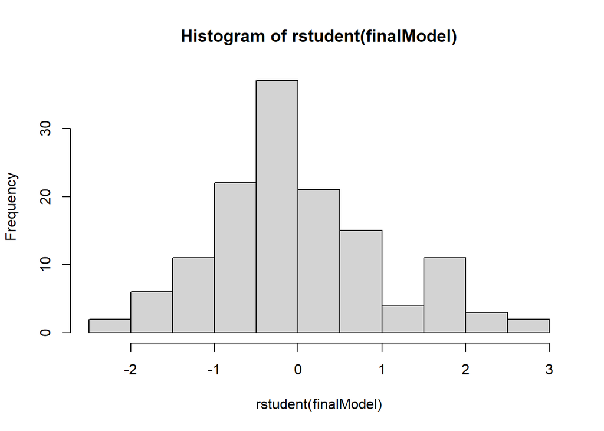

```
__Explanation:__
In addition, by looking at the residual histogram above, the model has a nearly normally distribution(roughly bell-shape), although not perfect, but nothing too extreme which means that this model is good enough.

As a result, this model can be deploy because this model has a pretty good accuracy of around 82%, but this model could be improve by exploring more attribute (independent variable) related to car price or adding more data for training the model.
```

```r
finalModel = (model5)
hist(rstudent(finalModel))
```